# Characteristic Classes

# 9 Thursday, September 16

Let $G\in {\mathsf{Grp}}$, and consider the following two categories. ${\mathbf{B}}G$ will be the category:

- ${\operatorname{Ob}}({\mathbf{B}}G) = \left\{{{\operatorname{pt}}}\right\}$.
- $\mathop{\mathrm{Mor}}_{{\mathbf{B}}G}({\operatorname{pt}}, {\operatorname{pt}}) = \left\{{g\in G}\right\}$, i.e. there is one morphism for every group element, with composition $g_1 \circ g_2 \mathrel{\vcenter{:}}= g_1g_2$ given by group multiplication.

$E G$ will be the category:

- ${\operatorname{Ob}}(EG) = \left\{{g\in G}\right\}$, one object for each element of $G$,
- $\mathop{\mathrm{Mor}}(g, h)=\left\{{g^{-1}h}\right\}$, a single (conveniently labeled!) morphism for each ordered pair $(g, h)$.

Note that $G\curvearrowright EG$:

[figure not shown]

> Link to Diagram

This induces an action on ${ \mathcal{N}({EG}) } \in {\mathsf{Top}}$, where the 0-simplices correspond to elements of $G$. and $n{\hbox{-}}$simplices are chains
$$\begin{align*}
g_0 \xrightarrow{g_0^{-1}g_1} g_1 \xrightarrow{g_1^{-1}g_2} g_2 \to \cdots \to g_n
.\end{align*}
Acting on this by \(G\) yields
\begin{align*}
gg_0 \xrightarrow{g_0^{-1}g_1} gg_1 \xrightarrow{g_1^{-1}g_2} gg_2 \to \cdots \to gg_n
,\end{align*}
noting we leave the morphism labeling unchanged, and that uniqueness of morphisms makes the simplicial boundary map behave nicely.$$

Show that
$$\begin{align*}
{ \mathcal{N}({EG}) }/G = { \mathcal{N}({{\mathbf{B}}G}) }
.\end{align*}$$

Note that
$$\begin{align*}
{ \mathcal{N}({{\mathbf{B}}G}) } &= \Delta^0 {\textstyle\coprod}\Delta^1 \times G {\textstyle\coprod}\Delta^2 \times G{ {}^{ \scriptscriptstyle\times^{2} } } {\textstyle\coprod}\Delta^3 \times G{ {}^{ \scriptscriptstyle\times^{3} } }\cdots \\
{ \mathcal{N}({E G}) } &= \Delta^0 \times G {\textstyle\coprod}\Delta^1 \times G{ {}^{ \scriptscriptstyle\times^{2} } } {\textstyle\coprod}\Delta^2 \times G{ {}^{ \scriptscriptstyle\times^{3} } }\cdots
,\end{align*}
where the gluing data for \({ \mathcal{N}({{\mathbf{B}}G}) }\) is given by
\begin{align*}
{{\partial}}_n:
\Delta^n \times G{ {}^{ \scriptscriptstyle\times^{n} } } &\to
\Delta^{n-1} \times G{ {}^{ \scriptscriptstyle\times^{n-1} } } \\
(\mathbf{x}, \mathbf{g}) &\mapsto (\mathbf{x}\setminus\left\{{x_n}\right\}, \mathbf{g} \setminus\left\{{g_n}\right\})
\end{align*}
and for \({ \mathcal{N}({EG}) }\) is
\begin{align*}
{{\partial}}_n: \Delta^n \times G{ {}^{ \scriptscriptstyle\times^{n+1} } } &\to
\Delta \times G{ {}^{ \scriptscriptstyle\times^{n} } } \\
(\mathbf{x}, \mathbf{g}) &\mapsto (\mathbf{x}\setminus\left\{{x_n}\right\}, \mathbf{g} \setminus\left\{{g_n}\right\})
.\end{align*}$$

The action $G\curvearrowright EG$ is the following:
$$\begin{align*}
g\cdot (\mathbf{x}, \mathbf{g}) \mapsto (\mathbf{x}, {\left[ {gg_0, gg_1,\cdots, gg_n} \right]} )
.\end{align*}$$

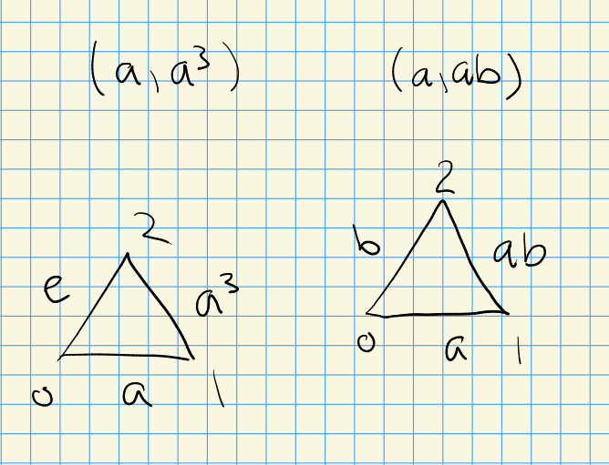

If $\mathsf{C}$ has an initial or terminal object, then ${ \mathcal{N}({\mathsf{C}}) }$ is contractible.

This clearly holds for $E G$, since every object is initial and terminal.

Suppose $y\in \mathsf{C}$ is terminal and any other object $x\in \mathsf{C}$, denote $f_x: x\to y$ the unique morphism.

Then for any sequence ending in $y$, deformation retract to $y$: $x_0 \xrightarrow{f_0} \to x_1 \xrightarrow{f_1} \cdots \xrightarrow{f_x} y \leadsto y$. If a sequence doesn’t end in $y$, add it on: $x_0 \xrightarrow{f_0} x_1 \cdots \to x_n {\color{green} \xrightarrow{f_{x_n}} y} \leadsto y$.

${ \mathcal{N}({EG}) }$ is contractible, and the quotient ${ \mathcal{N}({EG}) }\to { \mathcal{N}({{\mathbf{B}}G}) }$ is a universal $G{\hbox{-}}$bundle.

Construct $E G$ and ${\mathbf{B}}G$ for $G = C_4, C_2{ {}^{ \scriptscriptstyle\times^{2} } }$ and explicitly compare their 3-skeleta.

# 10 Tuesday, September 21

Today: a short discussion on generalizations of ${\mathbf{B}}G$ to topological groups.

A **topological category** is a category where the objects are topological spaces and morphisms form topological spaces in a coherent way, i.e. the following maps should be continuous:

- $\mathrm{source}, \mathrm{target}: \mathop{\mathrm{Mor}}_{\mathsf{C}} \to {\operatorname{Ob}}(\mathsf{C})$,
- $\operatorname{id}: {\operatorname{Ob}}(\mathsf{C})\to \mathop{\mathrm{Mor}}_{\mathsf{C}}$,
- Composition: $\mathsf{C}(x, y) \times \mathsf{C}(y,z) \to \mathsf{C}(x, z)$.

I.e. it is a category enriched over topological spaces (plus conditions).

If $G\in {\mathsf{Top}}{\mathsf{Grp}}$, then ${\mathcal{B}}G$ is a topological category since the morphism space $\mathop{\mathrm{Mor}}({\operatorname{pt}}, {\operatorname{pt}}) = G$ has a topology. Similarly ${\mathcal{E}}G$ is a topological category.

We can take nerves of topological categories; this just requires tracking the additional enrichment (i.e. the various topologies). The same proof will yield a principal $G{\hbox{-}}$bundle ${ \mathcal{N}({{\mathcal{E}}G}) } \xrightarrow{\pi} { \mathcal{N}({{\mathcal{B}}G}) }$, noting that $G$ again acts on ${ \mathcal{N}({{\mathcal{E}}G}) }$.

A space is called an **absolute neighborhood retract** (ANR) if for any $X\hookrightarrow Y$ (as a closed subspace) into a metric space, $X$ is a retract of a neighborhood in $Y$.

Every CW complex is an ANR. This is also true if every point of $X$ has a contractible neighborhood.

If $G$ is ANR, then $EG = { \mathcal{N}({{\mathcal{E}}G}) }\to { \mathcal{N}({{\mathcal{B}}G}) } = {\mathbf{B}}G \in \mathop{\mathrm{Prin}}{ {\mathsf{Bun}}\qty{G} }$.

Note that ${\mathbf{B}}G$ is a $\Delta{\hbox{-}}$complex, so we’ll try to build bundle charts by inducting over the skeleta. Each graded piece of the complex is of the form $\Delta^i \times G{ {}^{ \scriptscriptstyle\times^{i} } }$, so pick an interior point $((x_0, \cdots, x_i), (g_1,\cdots, g_i))$ so $x_i\neq 0$ for every $i$. Define a map
$$\begin{align*}
\Delta^i \times G{ {}^{ \scriptscriptstyle\times^{i} } } \times G &\to E G \\
( (x_0,\cdots, x_i), (g_1, \cdots, g_i), g) &\mapsto (\operatorname{id}(\cdots), (g, gg_1, gg_1g_2, \cdots, gg_1\cdots g_i))
,\end{align*}
which corresponds to the sequence of composable morphisms
\begin{align*}
(g \xrightarrow{g_1} gg_1 \xrightarrow{g_2} g g_1 g_2 \to \cdots \to gg_1\cdots g_i)
.\end{align*}$$

Show that this is not compatible with the gluing!

Write $p: \Delta^i \times G{ {}^{ \scriptscriptstyle\times^{i} } } \to {{\mathbf{B}}G}$ for the quotient attaching map, so we can write the $m{\hbox{-}}$skeleton as ${{\mathbf{B}}G}^{(m)} = \displaystyle\bigcup_{i\leq m} p(\Delta^i \times G{ {}^{ \scriptscriptstyle\times^{i} } })$. Now suppose $(U_m, \phi_m)$ is a chart for ${ \left.{{{\mathsf{E} G}}} \right|_{{{{\mathbf{B}}G}^{(m)}}} } \to{{\mathbf{B}}G}^{(m)}$, we want to extend this to a chart or ${{\mathbf{B}}G}^{(m+1)}$. We have a retraction $r: U_{m+1}\to U_m$ where $U_{m+1} \subseteq {{\mathbf{B}}G}^{(m+1)}$ is an open inclusion. We construct a trivialization of $\pi^{-1}(U_{m+1}) \to U_{m+1}$:

[figure not shown]

> Link to Diagram

This extends the chart to ${{\mathbf{B}}G}^{(m+1)}$, noting that $p$ is a quotient map and thus preserves open sets.

We can’t necessarily extend over the entire $m+1$ skeleton! But here extending it over a retractable neighborhood was enough, so we needed $G$ to be an ANR in order for ${{\mathbf{B}}G}$ to be an ANR. Why: consider
$$\begin{align*}
p^{-1}(U_m) \subseteq \displaystyle\bigcup_{i\leq m} \Delta^i \times G{ {}^{ \scriptscriptstyle\times^{i} } } \subseteq \displaystyle\bigcup_{i\leq m-1} \Delta^i \times G{ {}^{ \scriptscriptstyle\times^{i} } }
.\end{align*}
If \(G\) is an ANR, use that \(\Delta^i\) is an ANR and so their product will be, then pick a neighborhood and apply \(p\) to get the required open.$$

## 10.1 Building ${{\mathbf{B}}{\operatorname{O}}}_n$ and ${\mathsf{E} {\operatorname{O}}}_n$

We’ll assume all spaces paracompact from this point forward! We have a correspondence
$$\begin{align*}
\left\{{\substack{
\text{$n{\hbox{-}}$dimensional CW complexes }
}}\right\}
\rightleftharpoons
\left\{{\substack{
\text{$n{\hbox{-}}$dimensional vector bundles }
\\
\text{with an ${\operatorname{O}}_n{\hbox{-}}$structure}
}}\right\}
\rightleftharpoons
\mathop{\mathrm{Prin}}{\mathsf{Bun}}({\operatorname{O}}_n)_{/ {X}}
\rightleftharpoons
[X, {\mathbf{B}}{\operatorname{O}}_n]
\end{align*}
Our next goal is to construct \({{\mathbf{B}}{\operatorname{O}}}_n\) and \({\mathsf{E} {\operatorname{O}}}_n\) as spaces. Let \(V_n({\mathbb{R}}^k) \mathrel{\vcenter{:}}=\left\{{(\mathbf{v}_1, \cdots, \mathbf{v}_n) \text{orthonormal} }\right\}\). Note that \({\operatorname{O}}_n\curvearrowright V_n({\mathbb{R}}^k)\) by
\begin{align*}
\qty{\mathbf{v}_1, \cdots, \mathbf{v}_n}
\cdot A =
\qty{\sum_i a_{i, 1} \mathbf{v}_i,
\sum_i a_{i, 2} \mathbf{v}_i,
\cdots,
\sum_i a_{i, n} \mathbf{v}_i}
.\end{align*}$$

There is a projection

[figure not shown]

> Link to Diagram

We’ll use the fact that $V_1({\mathbb{R}}^k)$ is $(k-2){\hbox{-}}$connected, since it’s homotopy equivalent to $S^{k-1}$.

$V_n({\mathbb{R}}^{k})$ is $(k-n-1){\hbox{-}}$connected.

Induct on $n$ using the homotopy LES for the fiber bundle:

[figure not shown]

> Link to Diagram

Using the inclusions $V_n({\mathbb{R}}^k) \hookrightarrow V_n({\mathbb{R}}^{k+1})$, we can define $V_n({\mathbb{R}}^\infty) = \colim_k V_n({\mathbb{R}}^k) = \displaystyle\bigcup_{k\geq 0}V_n ({\mathbb{R}}^k)$. We equip it with the **weak topology**, i.e. $U \subseteq V_n({\mathbb{R}}^\infty)$ is open iff $U \cap V_n({\mathbb{R}}^k)$ is open for all $k$.

$$\begin{align*}
\pi_* V_n({\mathbb{R}}^\infty) = 0
.\end{align*}$$

By compactness, any sphere $S^m$ maps to $V_n({\mathbb{R}}^k)$ for some large $k$, and using $V_n({\mathbb{R}}^k) \hookrightarrow V_n({\mathbb{R}}^\ell)$ with $\ell-n-1 > m$ where $\pi_n V_n({\mathbb{R}}^\ell) = 0$ to make the map nullhomotopic.

$$\begin{align*}
V_n({\mathbb{R}}^\infty) / {\operatorname{O}}_n = {\operatorname{Gr}}_n({\mathbb{R}}^\infty)
.\end{align*}$$

It will turn out that ${\mathsf{E} {\operatorname{O}}}_n = V_n({\mathbb{R}}^\infty)$, sometimes referred to as the *Stiefel manifold* of $n{\hbox{-}}$frames in ${\mathbb{R}}^\infty$.

# 11 Thursday, September 23

Last time: we were trying to construct ${\mathsf{E} {\operatorname{O}}}_n$ and ${{\mathbf{B}}{\operatorname{O}}}_n$, and we defined $V_n({\mathbb{R}}^\infty) = \directlim_{k} V_n({\mathbb{R}}^k)$, where $V_n({\mathbb{R}}^k)$ was the space of $n$ orthonormal vectors in ${\mathbb{R}}^k$. There is a map $V_n({\mathbb{R}}^\infty)\to {\operatorname{Gr}}_n({\mathbb{R}}^\infty)$, which will be our candidate for ${\mathsf{E} {\operatorname{O}}}_n \to {{\mathbf{B}}{\operatorname{O}}}_n$.

$V_n({\mathbb{R}}^\infty) \xrightarrow{\pi} {\operatorname{Gr}}_n({\mathbb{R}}^\infty) \in \mathop{\mathrm{Prin}}{\mathsf{Bun}}({\operatorname{O}}_n)$.

We’ll show this directly in charts. Let $W\in{\operatorname{Gr}}_n({\mathbb{R}}^\infty)$ be an $n{\hbox{-}}$dimensional plane, the consider an open neighborhood
$$\begin{align*}
U_W \mathrel{\vcenter{:}}=\left\{{W' \in {\operatorname{Gr}}_n({\mathbb{R}}^\infty) {~\mathrel{\Big\vert}~}W^\perp \cap W' = 0}\right\}
.\end{align*}
For any such \(W'\), we have a map \(W'\to W\) given by orthogonal projection, which is an isomorphism since \(W^\perp \cap W' = 0\).$$

$$\begin{align*}
\pi^{-1}(U_W) \cong U_W \times {\operatorname{O}}_n
.\end{align*}$$

Fix some $\alpha\in \pi^{-1}(U_W)$ (an orthonormal basis for $W$), apply $f^{-1}$ to get $f^{-1}( \alpha)$, then apply Gram-Schmidt to get $\tilde a$, an orthonormal basis for $W'$. Define $F_{W'}$ to be this composition; this yields a bijection $\pi^{-1}(W) { { \, \xrightarrow{\sim}\, }}\pi^{-1}(W')$ for all $W'\in U_W$, namely
$$\begin{align*}
U_w \times {\operatorname{O}}_n &\to \pi^{-1}(W) \\
(W', A) &\mapsto F_{W'}( \alpha) \cdot A
.\end{align*}
The claim is that this trivializes the bundle, since this constructs a local section using \({\operatorname{O}}_n\) translations:$$

[figure not shown]

> Link to Diagram

Summary: pick an orthonormal basis for $W$, say $\alpha$, then $s(W) = \alpha$ and we define $s(W')$ by sending $\alpha$ to a basis for $W'$ by $P^{-1}$ and the applying Gram-Schmidt to get an orthonormal basis for $W'$.

- Replace ${\operatorname{O}}_n$ with $U_n$ and ${\mathbb{R}}$ with ${\mathbb{C}}$ to get ${\operatorname{Gr}}_n({\mathbb{C}}^\infty) = {\mathbf{B}}U_n$.
- $V_n({\mathbb{R}}^\infty)/ {\operatorname{SO}}_n = {\mathbf{B}}{\operatorname{SO}}_n$ yields the Grassmannian of *oriented* planes.
- For $H\leq G$, we have ${\mathbf{E}}H = {\mathbf{E}}G$ and ${\mathbf{B}}H = {\mathbf{E}}G/H$.

> Question: can you get ${\mathbf{B}}{\operatorname{Spin}}_n$ this way?

An alternative description of ${\mathsf{E} {\operatorname{O}}}_n$ and ${{\mathbf{B}}{\operatorname{O}}}_n$, due to Milnor-Stasheff: write ${{\mathbf{B}}{\operatorname{O}}}_n = {\operatorname{Gr}}_n({\mathbb{R}}^\infty)$ and define the **canonical bundle** $\gamma$. Recall that every principal ${\operatorname{O}}_n$ bundle is a pullback of the following form:

[figure not shown]

> Link to Diagram

Moreover, $\mathop{\mathrm{Prin}}({\operatorname{O}}_n)_{/ {X}} = [X, {{\mathbf{B}}{\operatorname{O}}}_n] = [X, {\operatorname{Gr}}_n({\mathbb{R}}^\infty)]$. Then $\gamma_n \xrightarrow{\pi} {\operatorname{Gr}}_n({\mathbb{R}}^\infty)$ is the ${\mathbb{R}}^n{\hbox{-}}$bundle where $\pi^{-1}(v) = v = V$, regarded as a plane in ${\mathbb{R}}^\infty$. Another description comes from the mixing construction: $\gamma_n = V_n({\mathbb{R}}^\infty) \overset{\scriptscriptstyle {{\operatorname{O}}_n} }{\times} {\mathbb{R}}^n \to {\operatorname{Gr}}_n({\mathbb{R}}^\infty)$.

[figure not shown]

> Link to Diagram

$E' \leq E$ is a **subbundle** iff there is an embedding $E' \hookrightarrow E$ over $X$:

[figure not shown]

> [Link to Diagram](https://q.uiver.app/?q=WzAsMyxbMCwwLCJFJyJdLFsyLDAsIkUiXSxbMSwyLCJYIl0sWzAsMiwiXFxwaSciLDJdLFsxLDIsIlxccGkiXSxbMCwxLCJmIiwwLHsic3R5bGUiOnsidGFpbCI6eyJuYW1lIjoiaG9vayIsInNpZGUiOiJ0b3AifX19XV0=)

We also require that restrictions to fibers $f_x: { \left.{{E'}} \right|_{{x}} } \to { \left.{{E}} \right|_{{x}} } \in \operatorname{Mat}(m\times n; {\mathbb{R}})$ is a linear map to an $n{\hbox{-}}$dimensional subspace ${ \left.{{E}} \right|_{{x}} }$, where $\dim_{\mathbb{R}}{ \left.{{E'}} \right|_{{x}} } = n$ and $\dim_{\mathbb{R}}{ \left.{{E}} \right|_{{x}} } = m$.

Every vector bundle $E \xrightarrow{\pi} X$ with $X\in {\mathsf{CW}}$ compact is a subbundle of a trivial bundle.

Take $\left\{{(U_i, \phi_i)}\right\}_{i=1}^m\rightrightarrows X$ a finite cover by charts, and choose a subordinate partition of unity $\left\{{\chi_i}\right\}_{i=1}^m$ such that $\mathop{\mathrm{supp}}\chi_i \subseteq U_i$. Then define
$$\begin{align*}
\psi: E &\to {\mathbb{R}}^{nm} =
{\mathbb{R}}^n \times {\mathbb{R}}^n \times \cdots \times {\mathbb{R}}^n
\\
v &\mapsto {\left[ {\chi_1(v) \phi_1(v), \chi_2(v) \phi_2(v), \cdots, \chi_m(v) \phi_m(v)} \right]}
.\end{align*}
This exhibits \((E \to X) \leq (X\times {\mathbb{R}}^{nm} \to X)\) as a subbundle.$$

Every $(E\to X)\in { { {\mathsf{Bun}}\qty{\operatorname{GL}_{n}} } }_{/ {X}}$ for $X\in {\mathsf{CW}}$ compact is a pullback of the canonical bundle along some map $f:X\to {{\mathbf{B}}{\operatorname{O}}}_n$.

For $E \xrightarrow{\pi} X$ and $f: X\to {{\mathbf{B}}{\operatorname{O}}}_n$, $\psi: E\to {\mathbb{R}}^{nm} \subseteq {\mathbb{R}}^\infty$ and we can take $f(x) \mathrel{\vcenter{:}}=\psi(\pi^{-1}(x)) \in {\operatorname{Gr}}_n({\mathbb{R}}^\infty)$ to get $f^* \gamma_n \cong E$.

If $f^* \gamma_n \cong E$ and $g^* \gamma_n \cong E$, then $f \simeq g$.

Corresponding to $f^* \gamma_n \cong E$ we get a map $\tilde f: E\to {\mathbb{R}}^{\infty}$ which restricts to an embedding on all fibers, and similarly $g^*\gamma_n \cong E$ yields $\tilde g: E\to {\mathbb{R}}^\infty$. So take
$$\begin{align*}
L_t: {\mathbb{R}}^\infty &\to {\mathbb{R}}^\infty \\
\mathbf{x} &\mapsto (t-1){\left[ {x_1,x_2,\cdots} \right]} + t{\left[ {x_1, 0, x_2, 0, x_3, 0, \cdots} \right]}
,\end{align*}
which is a homotopy between identity and the self-embedding that maps into only odd coordinates. Composing \(L_t \circ \tilde f\) yields a homotopy between \(\tilde f\) and a map \(F'\) whose image has only odd coordinates. Similarly, we can construct a \(G_t\) for \(\tilde g\) to get a homotopy between \(\tilde g\) and a map \(G'\) whose images has only even coordinates. Now take a linear homotopy \(F'\to G'\), this yields a homotopy through embeddings (where we’ve first made them “transverse”).$$

# 12 Vector Bundle Classification Theorem (Tuesday, September 28)

> See homework posted on the website! Turn in 2 total problem sets, one by mid-October.

$$\begin{align*}
[X, {{\mathbf{B}}{\operatorname{O}}}_n] \cong [X, {\operatorname{Gr}}_n({\mathbb{R}}^\infty)] &{ { \, \xrightarrow{\sim}\, }}{ {\mathsf{Bun}}\qty{\operatorname{GL}_{n}} }({\mathbb{R}}, X) \\
f & \mapsto f^* \gamma_n
.\end{align*}$$

We proved surjectivity last time for $X \in {\mathsf{CW}}$ compact, using compactness to embed any bundle into a trivial bundle. We proved injectivity in the form of $f^* \gamma_n \cong g^* \gamma_n \implies f\simeq g$, again for $X\in {\mathsf{CW}}$ compact. So we need to handle the case of $X$ not compact.

Let $\pi: E\to X$ be a vector bundle over $X$. Suppose for $B\in {\mathsf{CW}}$ compact with $B \subseteq X$, we have $f: B\to {\operatorname{Gr}}_n({\mathbb{R}}^\infty)$ such that $f^* \gamma_n \cong { \left.{{E}} \right|_{{B}} }$. Suppose also that there exists a $g: X\to {\operatorname{Gr}}_n({\mathbb{R}}^\infty)$ with $g^* \gamma_n \cong E$. Then there exists an $h: X\to{\operatorname{Gr}}_n({\mathbb{R}}^\infty)$ such that ${ \left.{{h}} \right|_{{B}} } = f$ and $h^* \gamma_n \cong E$.

[figure not shown]

Idea: write $X = \colim_n X^{(n)}$ as a limit of compact finite skeleta, define maps $f_n: X^{(n)} \to {{\mathbf{B}}{\operatorname{O}}}_n$ and $f_{n+1}: X^{(n+1)}\to {{\mathbf{B}}{\operatorname{O}}}_n$, then modify $\tilde f_{n+1} \simeq f_{n+1}$ to extend $f_n$ in such a way that $f_n^* \gamma_i = { \left.{{E}} \right|_{{B_n}} }$.

For $g^* \gamma_n \cong E$ with $({ \left.{{g}} \right|_{{B}} })^* \gamma_n \cong { \left.{{E}} \right|_{{B}} }$ and $f^* \gamma_n \cong { \left.{{E}} \right|_{{B}} }$, then $f\simeq{ \left.{{g}} \right|_{{B}} }$ by injectivity for compact $B$. We can then extend the homotopy $H: I\times X\to {{\mathbf{B}}{\operatorname{O}}}_n$ where $H_0 = g$ and $h\mathrel{\vcenter{:}}= H_1$ with ${ \left.{{h}} \right|_{{B}} } = f$.

## 12.1 Characteristic Classes

Let $F, G$ be two contravariant functors with source $\mathsf{C}$. A **characteristic class of $F$ valued in $\mathsf{G}$** is a natural transformation $c: F\to G$. $F$ is **representable** if there exists an object ${\mathbf{B}}F$ such that $F(X) = [X, {\mathbf{B}}F]$ for every $X\in {\operatorname{Ob}}(\mathsf{C})$.

> Note: we aren’t requiring the target categories to coincide!
- $F(X) \mathrel{\vcenter{:}}=\mathop{\mathrm{Prin}}{\mathsf{Bun}}({\operatorname{O}}_n)_{/ {X}} = { {\mathsf{Bun}}\qty{\operatorname{GL}_{n}} } {}_{/ {X}} = [X {{\mathbf{B}}{\operatorname{O}}}_n]$ is a contravariant functor ${\mathsf{ho}}{\mathsf{CW}}^{\operatorname{op}}\to {\mathsf{Set}}$, where contravariance is due to pullbacks.
- $G(X) \mathrel{\vcenter{:}}= H^j_{\mathrm{sing}}(X)$, which is representable: for any $X\in {\mathsf{CW}}$ and any $G\in {\mathsf{Ab}}{\mathsf{Grp}}$, we have $H^j(X; M) = [X, K(G, j)]$. This comes from taking the sphere that generates $\pi_j K(G, j) = \left\langle{\alpha}\right\rangle$ and pulling any $f: X\to K(G, j)$ back to $f^* \alpha$.

If $F = [{-}, {\mathbf{B}}F]$ is representable, then characteristic classes of $F$ valued in a functor $G$ biject with $G(B)$

We can write $F(B) = [B, B] \ni \operatorname{id}_B$, and it turns out that the characteristic class is determined by where $\operatorname{id}_B$ is sent:

[figure not shown]

> Link to Diagram

For us, taking $B\mathrel{\vcenter{:}}={\operatorname{Gr}}_n({\mathbb{R}}^\infty)$ and $G(B) = H^j({\operatorname{Gr}}_n({\mathbb{R}}^\infty)) \ni \alpha = c(\operatorname{id}_{B})$, so we can pullback to define $c(f) = f^*\alpha \in H^j(X)$.

Take $F(X) = \mathop{\mathrm{Prin}}{\mathsf{Bun}}(U_n)_{/ {X}} = [X {\operatorname{BU}}_n]$ and $G(X) = H^j(X)$, then $\alpha\in H^j({\operatorname{BU}}_n)$ maps to to $c_\alpha(E) = f^*(\alpha)$ for any $f\in [X, {\operatorname{BU}}_n]$.

Take $F(X) = H^n(X; M)$ and $G(X) = H^m(X; N)$ with $M, N \in {\mathsf{Ab}}{\mathsf{Grp}}$. Then $F(X) = [X, K(M, n)]$, and taking $G(K(M, n)) = H^m(K(M, n), N) \ni \alpha$ yields a map
$$\begin{align*}
H^n(X; M) &\to H^m(X; N) \\
(f: X\to K(M, n)) &\mapsto f^* \alpha
,\end{align*}
i.e. a cohomology operation. If for example
\begin{align*}
\phi \in \mathop{\mathrm{Hom}}_{\mathsf{Grp}}(M, N)
= \mathop{\mathrm{Hom}}_{\mathsf{Grp}}( H_n(K(M, n); {\mathbb{Z}}), N)
= H^n( K(M, n); N)
,\end{align*}
using that \(H_n(K(M, n); {\mathbb{Z}})\cong M\). This yields a change of coefficient morphism
\begin{align*}
H^n(X; M) \to H^n(X; N)
,\end{align*}
which turns out to be the same map as above. So any element in \(H^m(K(M, n), N)\) yields a map \(H^n(X, M)\to H^m(X, N)\) by sending \(f:X\to K(M, n)\) to \(f^*\alpha\). Taking \(n=m\) yields \(H^n(X; M)\to H^n(X; N)\).$$

# 13 Thursday, September 30

## 13.1 Line Bundles: Chern and Stiefel-Whitney Classes

Last time: defining characteristic classes. Recall that given $F, G \in {\mathsf{Fun}}({\mathsf{Top}}, {-})$, a characteristic class with values in $G$ is a natural transformation $c: F { { \, \xrightarrow{\sim}\, }}G$. If $F$ is representable, then characteristic classes $c: F\to G$ is of the form $c(\operatorname{id}_B) \in G(B)$ for $\operatorname{id}_B \in [B, B] \cong F(B)$, since $c$ is determined by where it sends $\operatorname{id}_B$. Recall that Eilenberg-MacLane spaces $K(G, n)$ represent $H^n({-}; G)$ for $G\in {\mathsf{Ab}}{\mathsf{Grp}}$, and are characterized by $\pi_i(K(G, n)) = G$ only in degree $i=n$.

- ${ {\mathsf{Bun}}\qty{\operatorname{GL}_{n}} }({\mathbb{R}}, X) { { \, \xrightarrow{\sim}\, }}[X, {{\mathbf{B}}{\operatorname{O}}}_n]$ and we realized ${{\mathbf{B}}{\operatorname{O}}}_n \simeq{\operatorname{Gr}}_n({\mathbb{R}}^\infty)$. For $\alpha\in H^j({{\mathbf{B}}{\operatorname{O}}}_n; {\mathbb{Z}})$, we can take a homotopy class $f:X\to {{\mathbf{B}}{\operatorname{O}}}_n$ and pullback to get $f^*(\alpha) \in H^j(X; {\mathbb{Z}})$.
- ${ {\mathsf{Bun}}\qty{\operatorname{GL}_{n}} }({\mathbb{C}}, X) { { \, \xrightarrow{\sim}\, }}[X, {\operatorname{BU}}_n]$, where ${\operatorname{BU}}_n \simeq{\operatorname{Gr}}_n({\mathbb{C}}^\infty)$ and we can again pullback cohomology classes.

For line bundles, we can identify ${\operatorname{BU}}_1 \simeq{\operatorname{Gr}}_1({\mathbb{C}}^\infty) \simeq{\mathbb{CP}}^\infty$, so ${ {\mathsf{Bun}}\qty{\operatorname{GL}_{1}} }({\mathbb{C}}, X) { { \, \xrightarrow{\sim}\, }}[X, {\mathbb{CP}}^\infty]$. The claim is that line bundles are uniquely characterized by their first Chern classes. Using that $H^2({\mathbb{CP}}^\infty; {\mathbb{Z}}) \cong {\mathbb{Z}}= \left\langle{\alpha}\right\rangle$, where we’ve chosen a positive generator, we obtain the **first Chern class** $c_1 \mathrel{\vcenter{:}}= f^*(\alpha) \in H^2(X; {\mathbb{Z}})$. Note that ${\mathbb{CP}}^\infty \simeq K({\mathbb{Z}}, 2)$, and $[X, K(G, n)] { { \, \xrightarrow{\sim}\, }}H^n(X; M)$ where $f\mapsto f^*(\alpha)$ for $H^n(K(G, n); {\mathbb{Z}}) = \left\langle{\alpha}\right\rangle$, so there is an isomorphism
$$\begin{align*}
[X, {\mathbb{CP}}^\infty] &{ { \, \xrightarrow{\sim}\, }}H^2(X; {\mathbb{Z}}) \\
f &\mapsto f^*(\alpha),\quad \left\langle{\alpha}\right\rangle = H^2({\mathbb{CP}}^\infty)
.\end{align*}
So the set of bundles is an affine space over \(H^2(X)\).$$

We can define $c_1$ for vector bundles of any dimension by taking a top exterior power to get a line bundle:

[figure not shown]

> Link to Diagram

So
$$\begin{align*}
c_1(E) \mathrel{\vcenter{:}}= c_1(\bigwedge\nolimits^n E)
.\end{align*}$$

There is a natural isomorphism $c(f^*(E)) \cong f^*(c(E))$, since we can take iterated pullbacks:

[figure not shown]

So we can identify $c(f^*(E)) = ( g\circ f)^* \alpha$ and $f^*(c(E)) = f^*(g^* \alpha) = (g\circ f)^* \alpha$.

## 13.2 Euler Classes and the Thom Isomorphism

Note that any vector bundle with a Riemannian metric admits a unit disc bundle.

A unit disc bundle $D \xrightarrow{\pi} B$ is **oriented** if there is a locally coherent choice of a generator of $H^n(D_b \mathrel{\vcenter{:}}=\pi^{-1}(b), S^b \mathrel{\vcenter{:}}={{\partial}}D_b; {\mathbb{Z}})$.

The unit disc bundle for an oriented $E \in { {\mathsf{Bun}}\qty{\operatorname{GL}_{n}} }({\mathbb{R}}, X)$ with a Riemannian metric will be oriented as a disc bundle.

Given a bundle $E\to X$ and taking its disc bundle ${\mathbb{D}}E\to X$, taking boundaries on fibers yields a sphere bundle ${\mathbb{S}}E\to X$, so ${\mathbb{S}}E_b \mathrel{\vcenter{:}}={{\partial}}{\mathbb{D}}E_b$ on fibers. Note the ${\mathbb{D}}E \simeq X$ by a deformation retraction.

Let ${\mathbb{D}}E\to X\in { {\mathsf{Bun}}\qty{\operatorname{GL}_{n}} }({\mathbb{R}}, X)$ be an oriented disc bundle and ${\mathbb{S}}E \to X$ its corresponding sphere bundle. Then

1. $H^{i< n}({\mathbb{D}}E, {\mathbb{S}}E; {\mathbb{Z}}) = 0$
2. There exists a generator, the **Thom class** $u_E \in H^n({\mathbb{D}}E, {\mathbb{S}}E; {\mathbb{Z}})$ mapping to a distinguished generator of $H^n({\mathbb{D}}E_x, {\mathbb{S}}E_x)$, inducing isomorphisms
   $$\begin{align*}
   ({-}) \smile u_E : H^j( {\mathbb{D}}E) &{ { \, \xrightarrow{\sim}\, }}H^{j+n}({\mathbb{D}}E, {\mathbb{S}}E) && \forall j\geq 0 \\
   \eta &\mapsto \eta \smile u_E
   ,\end{align*}$$
- **Step 1**: Look locally to see why we might expect this result! If ${\mathbb{D}}E\to X$ is trivial, then the claims hold.
- **Step 2**: If the claims hold for ${ \left.{{{\mathbb{D}}E}} \right|_{{U}} }, { \left.{{{\mathbb{D}}E}} \right|_{{V}} }, { \left.{{{\mathbb{D}}E}} \right|_{{U \cap V}} }$, then it holds for ${ \left.{{{\mathbb{D}}E}} \right|_{{U \cup V}} }$. As a corollary, the claims hold for compact $X$.
- **Step 3**: Prove claims for $H^*({-}; k)$ for $k\in \mathsf{Field}$
- **Step 4**: Prove claims for $H^*({-}; {\mathbb{Z}})$.

So pick $u\in H^n({\mathbb{D}}^n, S^{n-1})$ be the generator specified by the orientation, and take $u_E \in H^n({\mathbb{D}}E, {\mathbb{S}}E; {\mathbb{Z}})$ to be the corresponding generator pulled back along the Kunneth isomorphism (which recall was induced by a cup product).

Use Mayer-Vietoris:

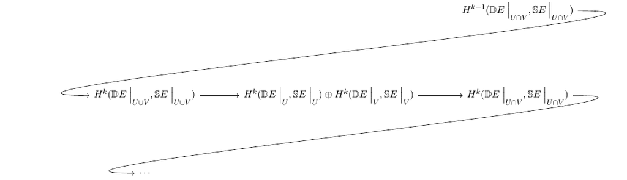

> Link to Diagram
- If $k< n$, the union terms vanish in degree $k$, since they’re surrounded by zeros.
- If $k=n$, the kernel of $\oplus \to \cap$ is isomorphic to ${\mathbb{Z}}$, so pick a generator $u_{U \cup V} = { \left.{{u_E}} \right|_{{U \cup V}} }$ that lifts ${ \left.{{u_E}} \right|_{{U}} }$ and ${ \left.{{u_E}} \right|_{{V}} }$.

Next time: we’ll show that $u_{U \cup V} \smile({-})$ yields the isomorphism in part 2 of the theorem statement.

# 14 Tuesday, October 05

Recall that we were proving the Thom isomorphism theorem. Some motivation:

Consider an oriented sphere bundle:

[figure not shown]

Then there is a LES induced by the Euler class $e\in H^n(X)$

[figure not shown]

> Link to Diagram

Corresponding to ${\mathbb{S}}E \xrightarrow{\pi} X$, the mapping cone of $\pi$ is ${\mathbb{D}}E$. So consider the LES in relative homology:

[figure not shown]

> Link to Diagram

After identifying terms, we see that $u_E \in H^n({\mathbb{D}}E,{\mathbb{S}}E)$ maps to the Euler class $e\in H^n(X)$, which carries interesting geometric information.

Suppose the claim holds for compact $X$, and write $X = \displaystyle\bigcup_i C_i$ for $C_i$ compact CW skeleta. Then $H_i(X) = \colim_j H_i(C_j)$ since simplices are also compact. Note that
$$\begin{align*}
H^i(X; k)
&\cong H_i(X; k) {}^{ \vee }\\
&\mathrel{\vcenter{:}}=\mathop{\mathrm{Hom}}( H_i(X; k), k) \\
&= \mathop{\mathrm{Hom}}( \colim_j H_i(C_j;k); k) \\
&= \cocolim_j \mathop{\mathrm{Hom}}( H_i(C_j; k), k) \\
&= \cocolim_j H^i(C_j; k)
.\end{align*}$$

[figure not shown]

> Link to Diagram

Now use that the vertical maps become isomorphisms after a colimit, so the top map must become an isomorphism as well.

Consider $H_i({\mathbb{D}}E, {\mathbb{S}}E; {\mathbb{Z}}) \to \cocolim_j H_i( { \left.{{{\mathbb{D}}E}} \right|_{{C_j}} }, { \left.{{{\mathbb{S}}E}} \right|_{{C_j}} }; {\mathbb{Z}})$ Using universal coefficients, we have
$$\begin{align*}
H^i({\mathbb{D}}E, {\mathbb{S}}E; {\mathbb{Z}})
\cong \mathop{\mathrm{Hom}}( H_i({\mathbb{D}}E, {\mathbb{S}}E; {\mathbb{Z}}), {\mathbb{Z}})
\oplus \operatorname{Ext} ( H_{i-1}({\mathbb{D}}E, {\mathbb{S}}E; {\mathbb{Z}}), {\mathbb{Z}}) = 0 && i < n
,\end{align*}
since each summand will be zero. For \(i=n\), the Ext term vanishes, and we have
\begin{align*}
H^n({\mathbb{D}}E, {\mathbb{S}}E; {\mathbb{Z}})
&\cong \mathop{\mathrm{Hom}}( H_n({\mathbb{D}}E, {\mathbb{S}}E; {\mathbb{Z}}), {\mathbb{Z}}) \\
&\cong \mathop{\mathrm{Hom}}( \colim_j H_n( { \left.{{ {\mathbb{D}}E}} \right|_{{C_j}} } , { \left.{{ {\mathbb{S}}E}} \right|_{{C_j}} }; {\mathbb{Z}}), {\mathbb{Z}}) \\
&\cong \cocolim_j \mathop{\mathrm{Hom}}( H_n( { \left.{{ {\mathbb{D}}E}} \right|_{{C_j}} } , { \left.{{ {\mathbb{S}}E}} \right|_{{C_j}} }; {\mathbb{Z}}), {\mathbb{Z}}) \\
&\cong \cocolim_j H_n( { \left.{{ {\mathbb{D}}E}} \right|_{{C_j}} } , { \left.{{ {\mathbb{S}}E}} \right|_{{C_j}} }; {\mathbb{Z}}) \\
&\cong \left\langle{u_E}\right\rangle \cong {\mathbb{Z}}
,\end{align*}
using the distinguished generator \(u_E \in H^n({\mathbb{D}}E, {\mathbb{S}}E)\). So we can define a chain map
\begin{align*}
u_E \frown({-}): C_{j+n}({\mathbb{D}}E, {\mathbb{S}}E; {\mathbb{Z}}) \to C_j({\mathbb{D}}E)
,\end{align*}
which shifts degree by \(-n\) by capping against \(u_E\). This induces the cup product \(u_E \smile({-}):H^j({\mathbb{D}}E; {\mathbb{Z}}) \to H^{j+n}({\mathbb{D}}E, {\mathbb{S}}E; {\mathbb{Z}})\).$$

Given chain complexes of ${\mathbb{Z}}{\hbox{-}}$modules $C_*$ and $D_*$ and a chain map $f:C_* \to D_*$, if $f^*: H^*(D_*; k) \to H_*(C_*; k)$ are isomorphisms for every $k\in \mathsf{Field}$, then $f_*, f^*$ are isomorphisms over any $R\in \mathsf{Ring}$.

We showed that $u_E \smile({-})$ was an isomorphism for all $k$, so now we get an isomorphism over every $R$ and this completes the proof.

Without the oriented assumption, this theorem still holds with $C_2$ coefficients.

Note also that we have naturality for characteristic classes: given a pullback

[figure not shown]

> [Link to Diagram](https://q.uiver.app/?q=WzAsNCxbMiwwLCJFIl0sWzIsMiwiWCJdLFswLDIsIlkiXSxbMCwwLCJmXiogRSJdLFszLDBdLFswLDFdLFsyLDFdLFszLDJdLFszLDEsIiIsMSx7InN0eWxlIjp7Im5hbWUiOiJjb3JuZXIifX1dXQ==)

Then
$$\begin{align*}
c(f^* E) = f^*c(E)
.\end{align*}
Note that we can always pull back the canonical:$$

[figure not shown]

> Link to Diagram

If the Euler class $e$ is natural, then $e(f^* \gamma_n) = f^* e(\gamma_n)$ where $e(\gamma_n) \in H^n({\operatorname{Gr}}_n({\mathbb{R}}^\infty))$, so $e$ is the characteristic class defined by $e(\gamma_n)$.

The Euler class $e$ is natural with respect to pullback and thus a characteristic class.

We’ll check naturality for the Thom class $u_E$. Consider pulling back a disc bundle:

[figure not shown]

> Link to Diagram

Recall that $u_E \in H^n({\mathbb{D}}E, {\mathbb{S}}E; {\mathbb{Z}})$ such that ${ \left.{{u_E}} \right|_{{x}} }: H^n( { \left.{{{\mathbb{D}}E}} \right|_{{x}} }, { \left.{{{\mathbb{S}}E}} \right|_{{x}} }; {\mathbb{Z}})$ is the generator. We get an element in the fibers of the pullback in the following way:

[figure not shown]

> Link to Diagram

We then get naturality of the Euler class from the following:

[figure not shown]

> Link to Diagram

$e({\mathbb{CP}}^1)$ is a generator of $H^2({\mathbb{CP}}^1)$ Apply the Gysin sequence, taking the canonical line bundle ${\mathbb{S}}E$ over ${\mathbb{CP}}^1$:

[figure not shown]

> Link to Diagram

The claim is that the total space here is the Hopf fibration:

[figure not shown]

What is the Hopf fibration? Write ${\mathbb{CP}}^1 = \left\{{{\left[ {z_0: z_1} \right]} {~\mathrel{\Big\vert}~}z_0^2 + z_1^2 = 1}\right\}/\sim$, then realize $S^3 = \left\{{z_0^2 + z_1^2 = 1}\right\} \subseteq {\mathbb{C}}^2$. Then take a map $S^3\to {\mathbb{CP}}^1$, whose fibers are $\left\{{\lambda \in {\mathbb{C}}{~\mathrel{\Big\vert}~}{\left\lvert {\lambda } \right\rvert}= 1}\right\} = {\mathbb{C}}^{\times}\cong S^1$. Then identifying elements and maps in the Gysin sequence yields the following:

[figure not shown]

> Link to Diagram

So $e$ is a generator of $H^2({\mathbb{CP}}^1)$

Check that ${\mathbb{S}}E\to {\mathbb{CP}}^1$ with ${\mathbb{S}}E$ the canonical is the Hopf fibration.

Try to compute $e({\mathbf{T}}S^2)$! You may need to add on a bundle to trivialize it.

# 15 Thursday, October 07

## 15.1 The Euler Class

Let $E\to X$ be an orientable bundle, then

[figure not shown]

> Link to Diagram

$e(-E) = -e(C)$.

Using naturality:

[figure not shown]

> Link to Diagram

Then $e({\mathbb{R}}^n\to {\operatorname{pt}}) = 0$, and $0 = f^*(0) = e(f^*({\mathbb{R}}^n\to {\operatorname{pt}})) = e(E)$.

$e(E) = 0$ if $E$ is the trivial bundle.

Using the exact sequence for the pair $({\mathbb{D}}E, {\mathbb{S}}E)$:

[figure not shown]

> Link to Diagram

So the second map is the inclusion $\alpha \mapsto (\alpha, 0)$, which is thus injective. The first map is 0, so $e(E) = 0$.

Compute $e( {\mathbf{T}}S^2)$.

If $E$ is an odd dimensional vector bundle, then $2e(E) = 0$

Check that $\alpha \smile\beta = (-1)^{ij} \beta \smile\alpha$.

The antipodal map will give an isomorphism $E\cong -E$, so $e(E) = e(-E) = -e(E)$ and thus $2e(E) = 0$.

Use the map:

[figure not shown]

> Link to Diagram

Then $2u_E \smile u_E = 0$, making $2u_E = 0$ and thus $2e(E) = 0$.

Given $X\to X$ and $F\to Y$, then we can form the bundle $E\times F\to X\times Y$. Writing $\pi_1:X\times Y\to X$ and $\pi_2:X\times Y\to Y$, we have
$$\begin{align*}
e(E\times F) = \pi_1^*(e(E)) \smile\pi_2^*(e(F)) = e(E) \otimes e(F)
.\end{align*}$$

Prove this using the Kunneth formula.

Let $E,E'\to X$ be two vector bundles. Then $e(E \oplus E') = e(E) \smile e(E')$.

Consider the diagonal $\Delta: X\to X{ {}^{ \scriptscriptstyle\times^{2} } }$, then take the pullback:

[figure not shown]

> Link to Diagram

Then
$$\begin{align*}
e(E \oplus E')
&= \Delta^*( e(E\times E'))\\
&= \Delta^*(\pi_1^*(e(E)) \smile\pi_2^*(e(E')) ) \\
&= \Delta^* \pi_1^* (e(E))\smile\Delta^* \pi_2^* e(E') \\
&= e(E) \smile e(E')
.\end{align*}$$

If $E' = L \oplus E$ for $L$ a trivial line bundle, $e(E') = 0$.

$$\begin{align*}
e(E') = e(L) \smile e(E) = 0
.\end{align*}$$

## 15.2 Obstruction Theory

The Euler class is the **obstruction** to finding a nonvanishing section over the $n{\hbox{-}}$skeleton of $X$. Note that if we have a line bundle, we automatically have a section. Conversely, a nonvanishing section will produce a line bundle summand.

Describe the correspondence between line subbundles and nonvanishing global section.

Some review: let $X\in {\mathsf{CW}}$ and write $H^*(X; {\mathbb{Z}})$ for cellular homology. Then $C^k_{{ \mathrm{cell}} }(X) = \mathop{\mathrm{Hom}}(H_k(X^{(k)}, X^{(k-1)} ), {\mathbb{Z}}) = \mathop{\mathrm{Hom}}(C_k^{{ \mathrm{cell}} }, {\mathbb{Z}})$. To produce the differential (green), use that the LES for the pairs (red and blue) are intertwined:

[figure not shown]

> Link to Diagram

Thus we have a formula
$$\begin{align*}
{\left\langle { \delta \alpha},~{ [\Delta^{k+1}] } \right\rangle} = {\left\langle { \alpha},~{ {{\partial}}[\Delta^{k+1}] } \right\rangle}
.\end{align*}$$

Recall that if the fibers of a bundle were $n{\hbox{-}}$connected, we could construct sections on $X^{(n-1)}$. Given any section, we can use a Riemannian metric to project onto norm 1 elements to get a section for the sphere bundle, say $s: X^{(n-1)} \to {\mathbb{S}}E$. Note that $\pi_i(S^{n-1}) = 0$ for $i\leq n-2$, so we can construct such a section. Let $i: \Delta^n\to X$ be the attaching map for some $n{\hbox{-}}$cell, then form the following pullback to get a trivial bundle, where we can pull back the section:

[figure not shown]

> Link to Diagram

So $s$ yields a map ${{\partial}}\Delta^n \cong S^{n-1} \to S^{n-1}$, so it has a degree. Then a cocycle can be defined as $[\Delta^n] \xrightarrow{e_s} \deg( {{\partial}}\Delta^n \to S^{n-1})\in {\mathbb{Z}}$.

$e_S$ is independent of the choice of trivialization for the pullback.

Since $\Delta^n$ is contractible, any two trivializations are homotopic. Thus the sections $s_T, s_{T'}: {{\partial}}\Delta^n \to S^{n-1}$ corresponding to two trivializations are homotopic.

If $s'$ is a different section over $X^{(n-1)}$, then $e_{s'} - e_s = \delta(\alpha)$ for some $\alpha\in C^{n-1}_{{ \mathrm{cell}} }(X)$.

See phone notes.

# 16 Tuesday, October 12

## 16.1 More Euler Class

> Review how to construct the Euler and Thom classes.

Recall that the Euler class is the obstruction to finding a nowhere vanishing section on the $n{\hbox{-}}$skeleton. Given $E\to X \in { {\mathsf{Bun}}\qty{\operatorname{GL}_r} }(X)^{\dim = n}$, we can form the sphere bundle $S^{n-1}\to {\mathbb{S}}E \to X$. Define a section $s: X\to {\mathbb{S}}E$ over $X{ {}^{ (0) } }$, then inductively if $s$ is defined over $X{ {}^{ (i-1) } }$ for $i<n$, let $j: \Delta^i \to X{ {}^{ (i) } }$ be the attaching map for an $i{\hbox{-}}$cell. Note that $\Delta^i$ is contractible, and we can form a pullback

[figure not shown]

If $s$ is defined over $X{ {}^{ (i-1) } } \subseteq X{ {}^{ (i) } }$, we have ${ \left.{{s}} \right|_{{{{\partial}}\Delta^i}} }: {{\partial}}\Delta^i \to S^{n-1}$. But ${{\partial}}\Delta^{i} \cong S^{i-1}$, and if $i\leq n-1$, $\pi_i S^{n-1} = 0$ so $s$ extends over $\Delta^i$. If $i=n$, note that $\pi_{n-1} S^{n-1} \cong {\mathbb{Z}}$, so we define $e_s(\Delta^n)$ to be the corresponding homotopy class of $s$, i.e. $e_s(\Delta^n)$ is the degree of this map between spheres.

We showed that

- $e_s$ doesn’t depend on the trivialization chosen, and
- If $s'$ is another nowhere vanishing section on $X{ {}^{ (n-1) } }$, then $e_s - e_{s'} \in \operatorname{im}\delta$ for $\delta: C^{n-1}(X) \to C^n(X)$.
- If $\delta e_s = 0$, then $[e_s] \in H^n(X; {\mathbb{Z}})$. The content here is that the cochain descends to a cocycle.

For $i:\Delta^{-1} \to X{ {}^{ (n-1) } }$ and ${\mathbb{S}}E\to X{ {}^{ (n-1) } }$, form the pullback $i^* {\mathbb{S}}E$. Generally given two sections $s, s': \Delta^{n-1} \to i^* {\mathbb{S}}E \cong \Delta^{n-1} \times S^{n-1}$, we can glue them to define a map $-\Delta^{n-1} {\textstyle\coprod}_{{{\partial}}} \Delta^{n-1} \xrightarrow{-s {\textstyle\coprod}s'} S^{n-1}$. The glued space is an $S^{n-1}$, so the degree of this map will be $\alpha^{\Delta^{n-1}}$

For any $\alpha\in C^{n-1}(X)$, there exists a section $s'$ on $X{ {}^{ (n-1) } }$ such that $e_{s'} - e_s = \delta \alpha$.

Prove this!

$[e_s] \in H^n(X)$ agrees with the Euler class.

We can equivalently define $e_s$ as follows: extend $s$ to any section $\mkern 1.5mu\overline{\mkern-1.5mus\mkern-1.5mu}\mkern 1.5mu$ of the disc bundle ${\mathbb{D}}E \to X$. Then for any $n{\hbox{-}}$cell $\Delta^n$, we can form the composition:

[figure not shown]

> Link to Diagram

We can then define $e_s(\Delta^n) \mathrel{\vcenter{:}}=\deg \psi$, and we claim that this also equals $\deg \psi'$. Look at the LES of a pair:

[figure not shown]

> Link to Diagram

We may assume that $X$ is $n{\hbox{-}}$dimensional since for $(X, X{ {}^{ (n) } })$ we have
$$\begin{align*}
H^n(X, X{ {}^{ (n) } }) = 0 \to H^n(X) \hookrightarrow H^n(X^n)
,\end{align*}
so anything equal in \(H^n(X{ {}^{ (n) } })\) must be equal in \(H^n(X)\). Fix a positive generator \(\left\langle{x}\right\rangle = H^n({\mathbb{D}}^n, S^{n-1})\) and \(\left\langle{y}\right\rangle = H_n(\Delta^n, {{\partial}}\Delta^n)\) to be the fundamental class (positive generator). Then
\begin{align*}
e_s(\Delta^n) = {\left\langle {\mkern 1.5mu\overline{\mkern-1.5mus\mkern-1.5mu}\mkern 1.5mu^* p^* x},~{y} \right\rangle}
.\end{align*}
Consider the map \((\Delta^n \times {\mathbb{D}}^n, {{\partial}}\Delta^n \times S^{n-1}) \xrightarrow{p} ({\mathbb{D}}^n, S^{n-1})\), we have \(p(\Delta^n\times S^{n-1}) = S^{n-1}\). Then we claim that \(p^*(x) = u\) will be the Thom class. Using the attaching map \(i: \Delta^n \to X{ {}^{ (n) } }\), we obtain
\begin{align*}
H^n({\mathbb{D}}E, {\mathbb{S}}E) \xrightarrow{i^*} H^n(\Delta^n \times {\mathbb{D}}^n, \Delta^n \times S^{n-1})
.\end{align*}$$

Use that $\mkern 1.5mu\overline{\mkern-1.5mus\mkern-1.5mu}\mkern 1.5mu: X\to {\mathbb{D}}E$ induces an isomorphism $\mkern 1.5mu\overline{\mkern-1.5mus\mkern-1.5mu}\mkern 1.5mu^*: H^n({\mathbb{D}}E)\to H^n(X)$, inducing the same isomorphism as the zero section. So $(s')^* = \mkern 1.5mu\overline{\mkern-1.5mus\mkern-1.5mu}\mkern 1.5mu^*$, i.e. any two sections of the disc bundle will be homotopic and thus induce equal maps in homology. Now doing exactly what we did for the Euler class, we get a diagram:

[figure not shown]

> Link to Diagram

More directly, we can map the LESs to get a commutative square:

[figure not shown]

> Link to Diagram

In other words, regard $e\in H^n_{ \mathrm{cell}} (X)$, so $e$ corresponds to $[c]\in \mathop{\mathrm{Hom}}_{{\mathsf{{\mathbb{Z}}}{\hbox{-}}\mathsf{Mod}}}(C^n(X), {\mathbb{Z}})$. We then claim that for $c\in H^n(X{ {}^{ (n) } }, X{ {}^{ (n-1) } })$, we have $e_s(\Delta^n) = i^* c(\Delta^n, {{\partial}}\Delta^n)$ using $i: (\Delta^n, {{\partial}}\Delta^n)\to (X{ {}^{ (n) } }, X{ {}^{ (n-1) } })$. Final diagram:

[figure not shown]

> Link to Diagram

## 16.2 Computations on Smooth Manifolds

Recall that a smooth structure on a manifold $M$ is a collection $(U, \phi_U)$ where $U \subseteq M$ is open, $\phi_U: U\to {\mathbb{R}}^n$ is a homeomorphism onto an open subset of ${\mathbb{R}}^n$, and for all $U, V$ we have
$$\begin{align*}
\psi_{VU} \mathrel{\vcenter{:}}=\phi_V^{-1}\circ \phi_U: \phi_U(U \cap V) \to \phi_V(U \cap V) \in C^\infty
,\end{align*}
so there are all diffeomorphisms of open subsets of \({\mathbb{R}}^n\). A smooth atlas is maximal if not contained in any other smooth atlas, and two atlases are compatible if their union is again a smooth atlas. We say two smooth structures are equivalent if they are compatible.$$

Show that any smooth manifold has a unique maximal smooth atlas.

Recall that for $f: {\mathbb{R}}^n\to {\mathbb{R}}^m$, $df\in \operatorname{Mat}(m\times n; {\mathbb{R}})$ is given by $(df)_{ij} = {\frac{\partial f_i}{\partial x_j}\,}$. For any $p\in U \cap V$, we have $d_{\phi_U(p)} \psi_{VU} \in \operatorname{GL}_n({\mathbb{R}})$, so we get a map $d\psi_{VU}: U \cap V\to \operatorname{GL}_n({\mathbb{R}})$. By the chain rule they satisfying the cocycle definition, so these glue to a vector bundle ${\mathbf{T}}M\to M$.

Show that every other definition of ${\mathbf{T}}M$ coincides with this one.

# 17 Thursday, October 14

Some background from smooth manifolds: a map $f:M\to N$ of manifolds is **smooth** if for any smooth charts $(U, \phi_U)$ and $(V, \psi_V)$ on $M, N$ respectively, the transition map $\psi_V \circ f \circ \phi_U ^{-1}{\mathbb{R}}^m\to{\mathbb{R}}^n$ is smooth.

1. Any smooth map $f:M\to N$ induces a bundle map $df: {\mathbf{T}}M\to f^* {\mathbf{T}}N$.
2. There is a canonical isomorphism ${\mathbf{T}}{\mathbb{R}}^n \to {\mathbb{R}}^n\times {\mathbb{R}}^n$.
3. Let $(U, \phi_U)$ be a chart on $M$, then show that there are trivializing charts for ${\mathbf{T}}M$:
   $$\begin{align*}
   d\phi_U: { \left.{{{\mathbf{T}}M}} \right|_{{U}} } \to { \left.{{ \phi_U^* }} \right|_{{ {\mathbf{T}}{\mathbb{R}}^n }} }{U} \cong U \times {\mathbb{R}}^n
   .\end{align*}
   In particular, the following diagram commutes:$$

[figure not shown]

> [Link to Diagram](https://q.uiver.app/?q=WzAsMyxbMCwwLCJcXHJve1xcVCBNfXtVfSJdLFswLDIsIlUiXSxbMiwwLCJVXFx0aW1lcyBcXFJSXm4iXSxbMCwxLCJcXHBpIl0sWzAsMiwiZFxccGhpX1UiXSxbMiwxXV0=)

Show that there is a canonical isomorphism
$$\begin{align*}
T_p M { { \, \xrightarrow{\sim}\, }}\mathop{\mathrm{Der}}(M, {\mathbb{R}}) \leq C^\infty(M, {\mathbb{R}})
,\end{align*}
where a derivation at \(p\) is a smooth functional \(v: C^\infty(M, {\mathbb{R}})\to {\mathbb{R}}\) such that \(v(fg) = v(f) g(p) + f(p) v(g)\).$$

$N \subseteq M$ is a **smooth submanifold** if for any $p\in N$ there exists a smooth chat $(U, \varphi)$ on $M$ such that $p\in U$ and $\phi(U \cap N) \subseteq {\mathbb{R}}^k \times\left\{{0}\right\} \subseteq {\mathbb{R}}^n$.

Show that this is equivalent to $N = f(\tilde N)$ where $\tilde N$ is some smooth manifold and $f:\tilde N\to M$ is a smooth embedding and $d_p f: {\mathbf{T}}_p \tilde N\hookrightarrow F_{f(p)} M$ is injective for all $p\in \tilde N$.

Given a Riemannian metric on ${\mathbf{T}}M$ and a smooth submanifold $N \subseteq M$, let $\nu N$ denote $({\mathbf{T}}N)^\perp \subseteq { \left.{{ {\mathbf{T}}M}} \right|_{{N}} }$ for the orthogonal complement of ${\mathbf{T}}N$. This is a vector bundle $\nu N \to N$.

Show that up to a canonical isomorphism, this is independent of the choice of Riemannian metric.

Given a curve $\gamma: I\to M$, then $\gamma'(t) \in {\mathbf{T}}_{\gamma(t)} M$ is the following derivation:
$$\begin{align*}
\gamma'(t) . f \mathrel{\vcenter{:}}=\lim_{h\to 0} { f(\gamma(t+h)) - f(\gamma(t)) \over h}
.\end{align*}
A vector field on \(M\) is a section of \({\mathbf{T}}M\), and a vector field along \(\gamma\) is a section of \(\gamma^* {\mathbf{T}}M\):$$

[figure not shown]

$\gamma'(t)$ is a vector field along $\gamma$.

A **Lie group** is a group $G$ with the structure of a smooth manifold where multiplication and inversion are smooth self-diffeomorphisms.

Given a Lie group $G$ and smooth principal $G{\hbox{-}}$bundle $P \xrightarrow{\pi} M^n$, a **connection** on $P$ is a choice of subspaces $\xi_p \subseteq T_p P$ for all $p\in P$ such that $d\pi: \xi_p \to {\mathbf{T}}_{\pi(p)} M$ is an isomorphisms for all $p$, where $\xi_p$ is the horizontal subspace:

[figure not shown]

Given a connection, curves $\gamma$ in $M$ can be lifted to curves $\tilde \gamma$ in $P$ in such a way that tangents of $\tilde \gamma$ are projected to tangents of $\gamma$:

Given a connection on $P$ and a smooth path $\gamma: I\to M$, a horizontal lift $\tilde \gamma$ of $\gamma$ is a path $\tilde \gamma: I\to P$ such that $\tilde \gamma'(t) \in \xi_{\tilde \gamma(t)}$ and $\pi \circ \tilde \gamma = \gamma$.

[figure not shown]

Given a smooth path $\gamma$ and $\tilde \gamma(0)$, there is a unique horizontal lift $\tilde \gamma$ starting at $\tilde \gamma(0)$.

Consider $\mathop{\mathrm{Frame}}({\mathbf{T}}M)$, then recall that ${{\mathbf{T}}M} = \mathop{\mathrm{Frame}}({\mathbf{T}}M) \overset{\scriptscriptstyle {\operatorname{GL}_n({\mathbb{R}})} }{\times} {\mathbb{R}}^n$ by the mixing construction. Given a connection on $\mathop{\mathrm{Frame}}({\mathbf{T}}M)$, we can parallel transport vectors in ${\mathbf{T}}M$ along curves. This comes from taking $[F_0, v_0]$ and evolving $F_0$ along $F_t \mathrel{\vcenter{:}}=\tilde \gamma(t)$, choosing pairs $[F_t, v_0]$ for all $t$, and ending at $[F_t, v_0]$.

Show that parallel transport yields a well-defined map ${\mathbf{T}}_{\gamma(0)}M \to {\mathbf{T}}_{\gamma(1))}M$.

Given a Riemannian metric on ${\mathbf{T}}M$, there is a canonical connection $\nabla$, the **Levi-Cevita** connection, which is torsionfree (i.e. $\nabla_X Y - \nabla_Y X = [X, Y]$) for $X, Y$ vector fields and $\nabla_X Y$ denotes parallel transporting $Y$ along $X$.

A curve $\gamma$ is a **geodesic** if $\gamma'(t)$ is parallel.

For any $v\in {{\mathbf{T}}M}$, there is a unique geodesic $\gamma_v$ with $\gamma_v'(0) = v$.

There is a map
$$\begin{align*}
\exp: T_p M &\to M \\
v &\mapsto \gamma_v(1)
.\end{align*}
This is well-defined for \(v\) of small norm, and for all \(v\) if \(M\) is closed.$$

If $N \leq M$ is a submanifold, then $\exp$ defines a diffeomorphism from a neighborhood of the zero section in $\nu N$ to a neighborhood of $N$.

[figure not shown]

# 18 Tuesday, October 19

Today: computations involving the Euler class.

Let $M\in {\mathsf{sm}}{\mathsf{Mfd}}^{\dim =n}$ be closed and oriented, then noting that $e({\mathbf{T}}M) \in H^n(M; {\mathbb{Z}})$,[^2]

$$\begin{align*}
{\left\langle { e({\mathbf{T}}M)},~{ [M] } \right\rangle} = \chi_{\mathsf{Top}}(M)
,\end{align*}
the topological Euler characteristic of \(M\).$$

Let $M\in {\mathsf{sm}}{\mathsf{Mfd}}^{\dim = n}$ closed and $E \xrightarrow{\pi} M \in { {\mathsf{Bun}}\qty{\operatorname{GL}_{k}} }(X)$ oriented. Suppose a generic section $s$ of $E$, i.e. $\operatorname{im}s \mathrel{\vcenter{:}}=\left\{{s(x) \in E {~\mathrel{\Big\vert}~}x\in M}\right\} \subseteq E$, intersects $M \subseteq E$ transversally. Then

- $z\mathrel{\vcenter{:}}= s^{-1}(0)$ is a submanifold of $M$ is a submanifold of $M$
- ${ \left.{{ds}} \right|_{{Z}} }: \nu Z { { \, \xrightarrow{\sim}\, }}{ \left.{{E}} \right|_{{Z}} }$

Prove this.

$e(E) = \mathrm{PD}([Z])$, where $[Z] \in H_{n-k}(M)$.

The second theorem implies the first.

Note that a section of ${\mathbf{T}}M$ is a vector field. Use Morse functions $f: M\to {\mathbb{R}}$:

- $\operatorname{crit}(f) = \left\{{p\in M {~\mathrel{\Big\vert}~}df_p = 0}\right\}$.
- $p\in \operatorname{crit}(f)$ is **nondegenerate** if the Hessian $H_p(f) \mathrel{\vcenter{:}}=\qty{ {\partial^2 \over \partial x_i \partial x_j } } (p)$ is nonsingular, i.e. $\operatorname{det}H_p\neq 0$.
- $f$ is **Morse** if all critical points are nondegenerate.
- If $p\in \operatorname{crit}(f)$ is nondegenerate, then $\operatorname{Ind}_p(f)$ is the number of negative eigenvalues of $H_p$.
- $f$ Morse on $M$ induces a CW complex structure with exactly one $k{\hbox{-}}$cell corresponding to each index $k$ critical point $p\in \operatorname{Crit}(f)_k$. Thus we can compute $\chi(M) = \sum_k (-1)^k \dim C_k^{ \mathrm{cell}} = \sum_k (-1)^k \# \operatorname{Crit}(f)_k$.

$f$ Morse induces a gradient vector field on $M$: picking a Riemannian metric $g$ on $M$, define $df({-}) \mathrel{\vcenter{:}}= g( \operatorname{grad}f, {-})$ to get a section $\operatorname{grad}f: M\to {\mathbf{T}}M$. Note that if $p\in \operatorname{crit}(f)$ then $d_p f = 0$ since $\operatorname{grad}_p f = 0$. So the vector field $df$ vanishes at $\operatorname{crit}(f)$ and $(\operatorname{grad}f)^{-1}(0)$

Show that the sign of a zero of the gradient vector field is $(-1)^{\operatorname{Ind}_p(f)}$.

So taking $Z = \operatorname{crit}(f)$, we can write
$$\begin{align*}
e({\mathbf{T}}M) = \mathrm{PD} { \left[ { \sum_{p\in \operatorname{crit}(f) } (-1)^{\operatorname{Ind}_p(f)} [x] } \right] }
,\end{align*}
where \([x]\) is the dual of a generator of \(H_0(M)\) Then
\begin{align*}
{\left\langle { e({\mathbf{T}}M)},~{ [M] } \right\rangle} = \sum_{p\in \operatorname{crit}(f) } (-1)^{\operatorname{Ind}_p(f)} = \# \operatorname{crit}_{\text{even}}(f) - \# \operatorname{crit}_{\text{odd}}(f) = \chi_{\mathsf{Top}}(M)
.\end{align*}$$

Given $N^n \hookrightarrow M^m$ an oriented closed submanifold with $M$ closed, we can consider Thom class of the disc/sphere bundles. We identify the disc bundle ${\mathbb{D}}\nu N$ with a tubular neighborhood of $N$ in $M$ and apply excision to get the following:

[figure not shown]

> Link to Diagram

We can also consider the composition:

[figure not shown]

> [Link to Diagram](https://q.uiver.app/?q=WzAsMyxbMCwwLCJbTl1cXGluIEhfbihOKSJdLFsyLDAsIkhfbihNKSJdLFs0LDAsIkhee20tbn0oTSkiXSxbMCwxLCJpXyoiXSxbMSwyLCJcXFBEIl1d)

These two classes are equal in $H^{m-n}(M)$.

Consider the following:

[figure not shown]

> Link to Diagram

The claim is that $u_{\nu N}$ is mapped to the *positive* generator, so the both paths from $H^{m-n}({\mathbb{D}}\nu N, {\mathbb{S}}\nu N)\to H^{m-n}(M)$ agree.

An aside on cup/cap products. The cap product is a map:
$$\begin{align*}
\frown: H_m(X) \otimes_{\mathbb{Z}}H^i(X) &\to H_{m-i}(X) \\
.\end{align*}
On chains, it’s given by
\begin{align*}
\frown C_m(X) \otimes_{\mathbb{Z}}C^i(X) &\to C_{m-i}(X) \\
(\sigma, \phi) &\mapsto \phi\qty{ { \left.{{\sigma}} \right|_{{{\left[ {v_0,\cdots, v_i} \right]}}} } } { \left.{{\sigma}} \right|_{{v_{i+1}, \cdots, v_m}} }
.\end{align*}
Then \(\mathrm{PD}({-}) \mathrel{\vcenter{:}}=[X]\frown({-})\).$$

The cup product is a map
$$\begin{align*}
\smile: H^i(X) \otimes_{\mathbb{Z}}H^j(X) &\to H^{i+j}(X) \\
C^i(X) \otimes_{\mathbb{Z}}C^j(X) &\to C^{i+j}(X) \\
(\phi, \psi) &\mapsto \qty{\sigma \mapsto \phi\qty{{ \left.{{\sigma}} \right|_{{[v_0,\cdots, v_i]}} }} \psi\qty{{ \left.{{\sigma}} \right|_{{[v_{i+1}, \cdots, v_{i+j}}} }} }
.\end{align*}
Then fixing any element yields a map \(\alpha \smile({-}): C^j(X) \to C^{i+j}(X)\), which is induced by a map \(\phi\frown({-}): C_{i+j}(X) \to C_i(X)\).$$

# 19 Thursday, October 21

Recall that if $N^n \leq M^n$ is a submanifold, we have the following diagram:

[figure not shown]

> Link to Diagram

Then the Thom class $u_{\nu N}\in H^{m-n}({\mathbb{D}}\nu N, {\mathbb{S}}\nu N) \to H^{m-n}({\mathbb{D}}\nu N_x, {\mathbb{S}}\nu N_x)$ is mapped to the generator specified by the orientations on fibers.

For $A^i \pitchfork B^j \leq X$ are smooth oriented submanifolds intersecting transversally, then
$$\begin{align*}
\mathrm{PD}([A]) \smile\mathrm{PD}([B]) &= \mathrm{PD}([A \frown B]) \\
H^{n-i}(X) \times H^{n-j}(X) &\to H^{2n-i-j}(X)
.\end{align*}$$

Then
$$\begin{align*}
[( {\mathbb{D}}\nu N_x, {\mathbb{S}}\nu N_x) \frown N] = [\left\{{x}\right\}]
,\end{align*}
which is the positive generator. So
\begin{align*}
\mathrm{PD}[ ({\mathbb{D}}\nu N_x, {\mathbb{S}}\nu N_x) ] \smile\mathrm{PD}[N] = \mathrm{PD}[x]
.\end{align*}
Now we can cap this to obtain
\begin{align*}
[{\mathbb{D}}\nu N, {\mathbb{S}}\nu N] \frown\qty{ \mathrm{PD}[ ({\mathbb{D}}\nu N_x, {\mathbb{S}}\nu N_x) ] \smile\mathrm{PD}[N]}
&=
\qty{ [{\mathbb{D}}\nu N, {\mathbb{S}}\nu N] \frown\mathrm{PD}[{\mathbb{D}}\nu N_x, {\mathbb{S}}\nu N_x] } \frown\mathrm{PD}[N] \\
&=
[{\mathbb{D}}\nu N, {\mathbb{S}}\nu N] \frown\mathrm{PD}[x] \\
&= 1
,\end{align*}
where we’ve used that \({\left\langle {\mathrm{PD}[x]},~{ [{\mathbb{D}}\nu N, {\mathbb{S}}\nu N] } \right\rangle}\). So \(\mathrm{PD}[N]\) is \(j^*\) of the Thom class of \(\nu N\).$$

Let $M \in {\mathsf{sm}}{\mathsf{Mfd}}^n$ be closed and oriented and $E \xrightarrow{\pi} M$ a $k{\hbox{-}}$dimensional oriented vector bundle. Consider a generic section $s$ of $E$, so $\operatorname{im}(s) \pitchfork M$ in $E$. Then
$$\begin{align*}
e(E) = \mathrm{PD}[Z] && Z \mathrel{\vcenter{:}}=\operatorname{im}(s) \cap M = s^{-1}(0)
.\end{align*}$$

Recall that $s^{-1}(0) \leq M$ is a smooth submanifold, and ${ \left.{{ds}} \right|_{{Z}} }: \nu Z { { \, \xrightarrow{\sim}\, }}{ \left.{{E}} \right|_{{Z}} }$, and since this orients $\nu Z$ this orients $Z$ as well.

Let $N$ be a tubular neighborhood of $Z$ in $M$, such that $N \cong {\mathbb{D}}\nu Z$. By the lemma, we have two maps

[figure not shown]

> Link to Diagram

on the other hand, since $Z \xhookrightarrow{i} M$, we get

[figure not shown]

> [Link to Diagram](https://q.uiver.app/?q=WzAsMyxbMCwwLCJcXHJve0V9e1p9Il0sWzIsMCwiRSJdLFsxLDIsIk4iXSxbMCwxLCJcXGlvdGEiXSxbMiwwLCJcXHJve2RzfXtafSJdLFsyLDEsInMiLDJdXQ==)

Show ${ \left.{{ds}} \right|_{{Z}} } \simeq s$ are homotopic sections.

Then $({ \left.{{ds}} \right|_{{Z}} })^* \circ i^* (u_E) = u_{\nu Z}$, so $u_{\nu Z} = s^* u_E$, and we have

[figure not shown]

> Link to Diagram

Since the diagram commutes, we get $e(E) = \mathrm{PD}[Z]$.

The Euler class for a bundle $E\to X\in {\mathsf{CW}}$ is the obstruction to finding a nowhere vanishing section on $X{ {}^{ (n) } }$ for $n\mathrel{\vcenter{:}}=\dim E$, and $e(E) = 0$ iff there is a nowhere vanishing section on $X{ {}^{ (n) } }$. For a smooth manifold $M$ and $E \xrightarrow{\pi} M$ with $\dim M = n, \dim E = k$ and $s:M\to E$ a section, then $\mathrm{PD}[s^{-1}(0)] = e[E]$ since $\dim s^{-1}(0) = n-k$. If $E = {\mathbf{T}}M$, then $e({\mathbf{T}}M) = 0$ implies $\chi(M) = 0$ and there exists a nowhere vanishing vector field.

# 20 Tuesday, October 26

For $F\to E \xrightarrow{\pi} B$ a fiber bundle with a $G{\hbox{-}}$structure, we have maps:

[figure not shown]

> [Link to Diagram](https://q.uiver.app/?q=WzAsMyxbMiwwLCJHIl0sWzIsMiwiXFxIb21lbyhGLCBGKSJdLFswLDIsIlxccGhpX3tpan0oVV9pIFxcaW50ZXJzZWN0IFVfaikiXSxbMCwxXSxbMiwxXSxbMiwwXV0=)

A vector bundle was an ${\mathbb{R}}^n$ bundle with a $\operatorname{GL}_n{\hbox{-}}$structure, having a Riemannian metric meant having an ${\operatorname{O}}_n$ structure, and orientability meant having a $\operatorname{GL}^+_n$ structure. A **principal** $G{\hbox{-}}$bundle was $P\to B$ where $P$ has a $G{\hbox{-}}$action acting freely and transitively on each fiber. Taking the frame bundle sent vector bundles to principal $\operatorname{GL}_n{\hbox{-}}$bundles.

We had a construction sending fiber bundles to principal $G{\hbox{-}}$bundles, namely the **clutching** construction: given ${\mathcal{U}}\rightrightarrows X$ and $\phi_{ij}: U_i \cap U_j \to G$ satisfying the cocycle condition $\phi_{ij} \phi_{jk} = \phi_{ik}$, we get a fiber bundle with fiber $F$ and transition functions for any $F\in{G{\hbox{-}}\mathsf{Spaces}}$.

On universal bundles and classifying spaces: for $X\in {\mathsf{CW}}$,
$$\begin{align*}
\mathop{\mathrm{Prin}}{ {\mathsf{Bun}}\qty{G} }(X) { { \, \xrightarrow{\sim}\, }}[X, {\mathbf{B}}G] \\
f^* EG &\mapsfrom f
.\end{align*}$$

We noted

- $G$ discrete implies ${\mathbf{B}}G \simeq K(G, 1)$
- $K(C_2, 1) = {\mathbb{RP}}^{\infty}$ with $EC_2 = S^{\infty}$
- ${\mathbf{B}}U_1 = {\mathbb{CP}}^{\infty}$ with $EU_1 = S^{\infty}$
- ${{\mathbf{B}}{\operatorname{O}}}_n = {\operatorname{Gr}}_n({\mathbb{R}}^{\infty})$, with ${\mathsf{E} {\operatorname{O}}}_n = V_n({\mathbb{R}}^{\infty})$ the Stiefel manifold of $n{\hbox{-}}$dimensional frames.
- ${\mathbf{B}}{\operatorname{SO}}_n$ are oriented $n{\hbox{-}}$planes in ${\mathbb{R}}^\infty$.
- For $H\leq G$, $EH = EG$ and ${\mathbf{B}}H = EG/H$.

We had a canonical bundle $\gamma_n \to {\operatorname{Gr}}_n({\mathbb{R}}^\infty)$ whose fiber above $W\leq {\mathbb{R}}^{\infty}$ was exactly $W$, so $\gamma_n = \left\{{(W, w\in W) \subseteq {\operatorname{Gr}}_n({\mathbb{R}}^\infty) \times {\mathbb{R}}^{\infty}}\right\}$. Every vector bundle $E\to X$ is of the form $f^* \gamma_n\to X$ for some $f\in [X, {\operatorname{Gr}}_n({\mathbb{R}}^\infty)]$, and similarly ${\operatorname{O}}_n$ bundles are pullbacks of $V_n({\mathbb{R}}^\infty)\to {\operatorname{Gr}}_n({\mathbb{R}}^\infty)$.

A useful application: characteristic classes. For any $c\in H^d({{\mathbf{B}}{\operatorname{O}}}_n)$ can be pulled back:
$$\begin{align*}
H^d(X) &\to { \mathsf{Vect} }_n(X) \\
f^*c &\mapsfrom f\in [X, {{\mathbf{B}}{\operatorname{O}}}_n]
.\end{align*}$$

Noting that ${\operatorname{BU}}_1 ={\mathbb{CP}}^\infty$ and $H^2({\mathbb{CP}}^\infty) = {\mathbb{Z}}\left\langle{c_1}\right\rangle$, so any line bundle $L\to X$ $f:X\to {\operatorname{BU}}_1$ yields $c_1(L) \mathrel{\vcenter{:}}= f^* c_1\in H^2(X)$, the **first Chern class**. Noting $H^2(X; {\mathbb{Z}}) \cong [X, K({\mathbb{Z}}, 2)] \cong [X, {\mathbb{CP}}^\infty]$.

Note: why $c_1=0$ in symplectic settings, related to Maslov index and ensures that the dimension of the relevant moduli space is zero.

# 21 Thursday, October 28

The Euler class is *natural* in the following sense: for $E\to X$ with $\dim E = n$ and $X\in {\mathsf{CW}}$, we can write

[figure not shown]

> Link to Diagram

Then naturality is the following equality:
$$\begin{align*}
e(E) = e(f^* \gamma_n) = f^*(e(\gamma_n))
.\end{align*}$$

Recall the Thom isomorphism theorem: for an oriented $E\in { {\mathsf{Bun}}\qty{\operatorname{GL}_r} }^n$, we have a disk bundle ${\mathbb{D}}E$ and sphere bundle ${\mathbb{S}}E$, and
$$\begin{align*}
H^j({\mathbb{D}}E; {\mathbb{S}}E) \cong
\begin{cases}
0 & j< n
\\
{\mathbb{Z}}& j=n
\\
H^{j-n}({\mathbb{D}}E) & j> n
\end{cases}
,\end{align*}
noting that we can take \(H^n({\mathbb{D}}E, {\mathbb{S}}E) \to H^n ({\mathbb{D}}E_x, {\mathbb{S}}E_x) { { \, \xrightarrow{\sim}\, }}H^n(D^n, S^{n-1})\), where the target has a canonical positive generator. The preimage of this generator is \(u_E\), the Thom class. The isomorphisms in the range \(j>n\) are given by \({-}\smile u_E\).$$

We had a claim:
$$\begin{align*}
H^n({\mathbb{D}}E, {\mathbb{S}}E) &\to H^n({\mathbb{D}}E) \cong H^n(X) \\
u_E &\mapsto e(E)
.\end{align*}$$

On the **Gysin sequence**: use the bundle $S^{n-1} \hookrightarrow{\mathbb{S}}E \to X$ and the LES
$$\begin{align*}
\cdots \to H^{j-1}({\mathbb{S}}E) \xrightarrow{\delta} H^{j-n}(X) \xrightarrow{({-}) \smile e(E)} H^j(X) \to H^j({\mathbb{S}}E) \to \cdots
.\end{align*}
The connecting map \(\delta\) comes from the Thom isomorphisms \(H^j({\mathbb{D}}E, {\mathbb{S}}E){ { \, \xrightarrow{\sim}\, }}H^{j-n}({\mathbb{D}}E)\) and splicing the LES of the pair \(({\mathbb{D}}E, {\mathbb{S}}E)\).$$

If $E$ is odd dimensional, then $2 e(E) = 0$. Note that $e(E_1 \oplus E_2) - e(E_1) \smile e(E_2)$, and if $E$ has a nonvanishing section then $e(E) = 0$.

So $e(E)$ is the obstruction to finding a nonvanishing section over the $n{\hbox{-}}$skeleton, where $\dim E = n$. Given a nonvanishing section over $X{ {}^{ (k-1) } }$, consider extending it over $X{ {}^{ (k) } }$. We can use the cellular attaching maps to write

[figure not shown]

> Link to Diagram
- If $s \in \pi_k(S^n)$ and $k<n$, it is nullhomotopic and can thus be extended from ${{\partial}}\Delta^k$ to $\Delta^k$.
- If $k=n$, we get $s_*: H_{n-1}({{\partial}}\Delta^n) \to H_{n-1}(S^{n-1})$ where $a\mapsto na$ with $n\mathrel{\vcenter{:}}=\deg(s_*)$. This yields an cellular $k{\hbox{-}}$cochain $C^k \to {\mathbb{Z}}$ where $\Delta^n \mapsto \deg s_*$, and this represents the Euler class.

For smooth manifolds, we have natural bundles ${\mathbf{T}}X$ and $\nu X$ to work with. Then
$$\begin{align*}
{\left\langle {e({\mathbf{T}}M)},~{ [M] } \right\rangle} = \chi(M)
,\end{align*}
using that \(e({\mathbf{T}}M) \in H^n(M) \cong {\mathbb{Z}}\). In general, so \(E\to M^n\) with a generic section \(s\), writing \(Z\mathrel{\vcenter{:}}= s^{-1}(0) \leq E\) a submanifold of dimension \(n-k\) when \(\dim Z = k\), we have \([Z] \in H_{n-k}(M)\) and \(\mathrm{PD}[Z]= e(E)\).$$

Consider $N^n \hookrightarrow M^{2n}$, then $\nu N\to N \in { {\mathsf{Bun}}\qty{\operatorname{GL}_r} }^n(N)$. To compute $e(\nu N)$, pick a generic section:

[figure not shown]

Then $e(\nu N) = N\cdot N \in H_n(M)$ is the self-intersection number.

For $N^n \subseteq M^m$, we have

[figure not shown]

> Link to Diagram

So we can compute $e(E)$ for ${\mathbf{T}}M$ and $\nu N$.

Next topics: Chern and Stiefel-Whitney classes.

For $E\to X$ a real vector bundle, there are characteristic classes $w_i(E) \in H^i(X; C_2)$ and $w \mathrel{\vcenter{:}}= 1 + w_1(E) + w_2(E) + \cdots \in H^*(E)$ , the **Stiefel-Whitney classes**, satisfying the following properties:

1. Naturality: $w_i(f^*(E)) = f^*(w_i(E))$
2. $w(E_1 \bigoplus E_2) = w(E_1 )\smile w(E_2)$
3. $w_i(E) = 0$ if $i>\dim_{\mathbb{R}}E$.
4. If $E\to {\mathbb{RP}}^\infty$ is the canonical line bundle, then $w_1(E) = \alpha$ for $\left\langle{\alpha}\right\rangle = H^1({\mathbb{RP}}^\infty; C_2)$.

Moreover, these properties characterize $w_i(E)$ uniquely. For complex vector bundles, there are $c_i(E) \in H^{2i}(X; {\mathbb{Z}})$ and $c_(E)$, the **Chern classes**, which satisfy the same properties with ${\mathbb{C}}$ instead of ${\mathbb{R}}$ and $\left\langle{\alpha}\right\rangle = H^2({\mathbb{CP}}^\infty; {\mathbb{Z}})$.

Next time: existence and uniqueness.

# 22 Stiefel-Whitney and Chern Classes (Tuesday, November 02)

The Stiefel-Whitney classes $w_i \in H^i(X; C_2)$ will be defined for ${ {\mathsf{Bun}}\qty{\operatorname{GL}_r} }(X)_{/ {{\mathbb{R}}}}$ while Chern classes $c_i \in H^{2i}(X; {\mathbb{Z}})$ will be defined for ${ {\mathsf{Bun}}\qty{\operatorname{GL}_r} }(X)_{/ {{\mathbb{C}}}}$. We setting $w(E) \mathrel{\vcenter{:}}=\sum_i w_i(E) \in H^*(X; C_2)$, we mentioned several properties:

- $w_i(f^* E) = f^* w_i(E)$
- $w(E_1 \oplus E_2) = w(E_1) \smile w(E_2)$
- $w_{> \dim E} E = 0$
- $w_1(\gamma)$ is the generator of $H^1({\mathbb{RP}}^\infty; C_2) = C_2$ where $\gamma \to {\mathbb{RP}}^\infty$ is the canonical line bundle. For complex bundles, $c_1(\gamma)$ is the positive generator of $H^2({\mathbb{CP}}^\infty; {\mathbb{Z}}) = {\mathbb{Z}}$.

These properties characterize the $w_i$ and $c_i$ uniquely.

On why we need $C_2$ coefficients: we’re pulling back $\gamma \to {{\mathbf{B}}{\operatorname{O}}}_1$ and ${{\mathbf{B}}{\operatorname{O}}}_1 \simeq{\mathbb{RP}}^\infty$ where $H^1({\mathbb{RP}}^\infty; {\mathbb{Z}}) = 0$! For line bundles, we’ll automatically have $w_{\geq 2} = 0$ for any such class, so we only have $w_1$ the work with, and this we need to pull back something nonzero to get anything interesting.

Some immediate consequences:

- $w_i(E \oplus {\mathbb{R}}) = w_i(E)$, this if $E$ is trivial then $w_i(E) = 0$ and $w(E) = 1$. Moreover $w(E \oplus {\mathbb{R}}) = w(E) w({\mathbb{R}}) = w(E)$ since $w({\mathbb{R}}) = 1$.
- If $E$ has $k$ linearly independent nonvanishing sections, then there is a splitting $E = E' \oplus R{ {}^{ \scriptscriptstyle\oplus^{k} } }$ where $\dim E' = n-k$. Thus $w_i(E) = 0$ for $i> n-k$.
- If $E_1 \oplus E_2$ is trivial, then $w(E_1) \smile w(E_2) = 1$.

If $M \subseteq {\mathbb{R}}^N$, then $w({\mathbf{T}}M) \smile w(\nu M) = 1$. If $S^n \subseteq {\mathbb{R}}^{n+1}$, then $w({\mathbf{T}}S^n) = 1$ since $w(\nu S^n) = 1$. So for example $w({\mathbf{T}}S^2) = 1$, but ${\mathbf{T}}S^2$ has no nonvanishing sections.

Consider inverting a formal power series $\sum_{i\geq 0} a_i$:
$$\begin{align*}
(1 + a_1 + a_2 + a_3 + \cdots)( 1 - a_1 + (a_1^2 + a_2) + (a_1^3 + 2a_1 a_2 - a_3) + \cdots) = 1
.\end{align*}$$

So if $w(E_1)w(E_2) = 1$, we can solve for $w(E_1)$ in terms of $w(E_2)$.

Note that $H^*({\mathbb{RP}}^n; C_2) = {\mathbb{F}}_2[a]/\left\langle{a^{n+1}}\right\rangle$ where $H^1({\mathbb{RP}}^n; C_2) = \left\langle{a}\right\rangle$. Claim: $w({\mathbf{T}}{\mathbb{RP}}^n) = (1+a)^{n+1}$

Let $\gamma\to {\mathbb{RP}}^n$ be the canonical line bundle, which is a pullback of $\gamma^\infty \to {\mathbb{RP}}^\infty$ and $\left\langle{ w_1(\gamma^\infty) }\right\rangle = H^1({\mathbb{RP}}^\infty; C_2)$. By the naturality property, $w_1(\gamma) = \alpha$ in $H^1({\mathbb{RP}}^n; C_2)$.

$$\begin{align*}
{\mathbf{T}}{\mathbb{RP}}^n = \mathop{\mathrm{Hom}}(\gamma, \gamma^\perp)
.\end{align*}$$

Recall that $\gamma \subseteq {\mathbb{RP}}^n \times {\mathbb{R}}^{n+1}$ as a subbundle over ${\mathbb{RP}}^n$, and $\gamma = \left\{{ ([\mathbf{x}], \lambda \mathbf{x}) {~\mathrel{\Big\vert}~}\lambda \in {\mathbb{R}}}\right\} = \pi^{-1}[\mathbf{x}]$. We can write ${\mathbf{T}}{\mathbb{RP}}^n = {\mathbf{T}}S^n/ (\mathbf{x}, \mathbf{v})\sim (- \mathbf{x}, - \mathbf{v})$, so
$$\begin{align*}
{\mathbf{T}}{\mathbb{RP}}^n
= \left\{{ [(x, v), (- \mathbf{x}, - \mathbf{v})] {~\mathrel{\Big\vert}~}v\in {\mathbf{T}}_x S^n }\right\}
= \left\{{ [(x, v), (- \mathbf{x}, - \mathbf{v})] {~\mathrel{\Big\vert}~}v\in {\mathbf{T}}_x S^n \iff {\left\langle {x},~{v} \right\rangle} = 0 }\right\}
.\end{align*}$$

So define a map
$$\begin{align*}
{\mathbf{T}}{\mathbb{RP}}^n &\to \mathop{\mathrm{Hom}}( \gamma, \gamma^\perp) \\
[(\mathbf{x}, \mathbf{v}), (-\mathbf{x}, \mathbf{v})] &\mapsto \qty{\lambda \mathbf{x} \xrightarrow{\ell} \lambda \mathbf{v} }
,\end{align*}
and one can check that this is well-defined.$$

[figure not shown]

We can thus write
$$\begin{align*}
{\mathbf{T}}{\mathbb{RP}}^n \oplus {\mathbb{R}}
&= \mathop{\mathrm{Hom}}( \gamma, \gamma^\perp) \oplus \mathop{\mathrm{Hom}}( \gamma, \gamma) \\
&= \mathop{\mathrm{Hom}}( \gamma, \gamma^\perp \oplus \gamma) \\
&= \mathop{\mathrm{Hom}}(\gamma, {\mathbb{R}}^{n+1}) \\
&= \mathop{\mathrm{Hom}}(\gamma, {\mathbb{R}}){ {}^{ \scriptscriptstyle\oplus^{(n+1)} } }
.\end{align*}$$

Note that $\mathop{\mathrm{Hom}}( \gamma, {\mathbb{R}}) \cong \gamma$, so $w({\mathbf{T}}{\mathbb{RP}}^n \oplus {\mathbb{R}}) = w(\gamma)^{n+1} = (1+a)^{n+1}$ and $w({\mathbf{T}}{\mathbb{RP}}^n \oplus {\mathbb{R}}) = w({\mathbf{T}}{\mathbb{RP}}^n)$.

$w({\mathbf{T}}{\mathbb{RP}}^n) = 1$ iff $n+1=2^r$ for some $r$.

$\impliedby$: By induction, $(1+a)^{2^r} = 1 + a^{2^r}$, using that $(1+a)^2 = 1 + a^2 + 2a$ and $2a=0$ when we have $C_2$ coefficients. Now write
$$\begin{align*}
(1+a)^{2^r} = ( (1+a)^{2^{r-1}} )^2 \overset{IH}{=} (1 + a^{2^{r-1}})^2 = 1 + a^{2^r}
.\end{align*}
Now use that \(\dim {\mathbf{T}}{\mathbb{RP}}^n = n\), so \((1+a)^{n+1} = 1\) since \(a^{2^r} = a^{n+1} = 0\).$$

$\implies$: Suppose $n+1 = m2^r$ with $m$ odd, then
$$\begin{align*}
(1 + a)^{ m2^{r}}
= ((1+a)^{2^r})^m \\
= (1+a^{2^r})^m \\
= 1 + ma^{2^r} + \cdots
,\end{align*}
where the first nontrivial term doesn’t vanish since \(a^{2^r}\neq 0\).$$

If ${\mathbb{RP}}^{2^r}$ admits an immersion into ${\mathbb{R}}^N$, then $N\geq 2^{r+1} - 1$.

Why?
$$\begin{align*}
w({\mathbf{T}}{\mathbb{RP}}^{2^r}) = (1+a)^{2^r+1} = (1+a)^{2^r}(1+a) \\
= (1+a^{2^r})(1+a) \\
= 1 +a + a^{2^r} + a^{2^r + 1} \\
= 1 +a + a^{2^r}
.\end{align*}
Try to invert this: let \(n\mathrel{\vcenter{:}}= 2^r\), then
\begin{align*}
(1+a+a^n)(1 + a + a^2 + \cdots + a^{n-1}) = 1
.\end{align*}$$

Then
$$\begin{align*}
w(\nu {\mathbb{RP}}^n) = \sum_{0\leq i \leq n-1} a^i
,\end{align*}
so \(\dim \nu {\mathbb{RP}}^n \geq n-1\).$$

# 23 Thursday, November 04

Recall that $w({\mathbf{T}}{\mathbb{RP}}^n) = (1+a)^{n+1}$ where $\left\langle{a}\right\rangle = H^1({\mathbb{RP}}^n; C_2)$, and as an application, if ${\mathbb{RP}}^{2^r} \hookrightarrow{\mathbb{R}}^N$, then $N \geq 2^{r+1} - 1$. Similarly, $c({\mathbf{T}}{\mathbb{CP}}^n) = (1+a)^{n+1}$ with $\left\langle{a}\right\rangle = H^2({\mathbb{CP}}^\infty; {\mathbb{Z}})$ the positive generator.

Fix a commutative ring $R$ and a fiber bundle $F\hookrightarrow E \to B$ such that

1. $H^j(F; R) \in {\mathsf{R}{\hbox{-}}\mathsf{Mod}}$ is finitely generated and free,
2. For any $j$, there exist $c_{j_k} \in H^j(E; R)$ such that the restrictions of $\left\{{c_{j_k}}\right\}_{k\geq 0}$ is a basis for $H^j(E_x; R) = H^j(F; R)$.

Then there is an isomorphism
$$\begin{align*}
\Phi: H^*(B; R)\otimes_R H^*(F; R){ { \, \xrightarrow{\sim}\, }}H^*(E; R) \\
b_i \otimes i^*(c_{j_k}) \mapsto \pi^*(b_i) \smile c_{j_k}
.\end{align*}$$

Let ${\mathbb{P}}(E)$ be the projectivization of $E$, so each vector space fiber $V$ is replaced with ${\mathbb{P}}(V)$. Let $\gamma \subseteq \pi^*(E)$ be the canonical over ${\mathbb{P}}(E)$, so the fibers are $\gamma_{(\gamma, [\gamma])} = \left\{{w\in E_x {~\mathrel{\Big\vert}~}w\in [v]}\right\}$. For $E\in { {\mathsf{Bun}}\qty{\operatorname{GL}_{n}} }({\mathbb{C}})_{/ {X}}$, pick a metric on $E$, and define $E' \mathrel{\vcenter{:}}=\gamma^\perp$. Now take the pullback:

[figure not shown]

> Link to Diagram

So we have a bundle ${\mathbb{CP}}^{n-1} \hookrightarrow{\mathbb{P}}(E) \to X$, we’ll now try to apply the theorem. Note that $H^*({\mathbb{CP}}^{n-1}; {\mathbb{Z}}) = {\mathbb{Z}}[u]/\left\langle{u^n}\right\rangle$, so $H^i$ is generated by $u^i$, fulfilling condition 1.

Let $\iota_x: E_x \hookrightarrow E$ be the inclusion of a fiber. If we restrict ${\mathbb{P}}(E)$ to a fiber ${\mathbb{P}}(E)_x$, this yields the canonical over ${\mathbb{CP}}^{n-1}$:

[figure not shown]

> Link to Diagram

Then $\iota_x^* c_1(\gamma) = c_1(\gamma_x) = e(\gamma_x) = u$, so we have condition 2.

For $L \in { {\mathsf{Bun}}\qty{\operatorname{GL}_{1}} }({\mathbb{C}})$,
$$\begin{align*}
c_1(L {}^{ \vee }) = c_1(L)
.\end{align*}$$

So we have classes $1, c_1(\gamma), c_1(\gamma)^2,\cdots, c_1( \gamma)^{n-1}$, and we can take duals to obtain $1, c_1(\gamma {}^{ \vee }), c_1(\gamma {}^{ \vee })^2,\cdots, c_1( \gamma {}^{ \vee })^{n-1}$. There exist $c_1(E), c_2(E), \cdots, c_n(E) \in H^*(X)$ such that we can write the former as a linear combination of the latter:
$$\begin{align*}
c_1( \gamma {}^{ \vee })^n + c_1(E) c_1( \gamma {}^{ \vee })^{n-1} + \cdots + c_n(E) = 0
,\end{align*}
and the \(c_i(E)\) are called the Chern classes.$$

Write $c(E) = 1 + c_1(E) + \cdots + c_n(E)$, so
$$\begin{align*}
\pi^* c(E)
&= c(\gamma) c(E') = (1 +c_1(\gamma))(1 + c_1(E') + \cdots + c_{n-1}(E'))\\
&= 1 + (c_1(\gamma) + c_1(E'))
+ (c_1( \gamma)c_1(E') + c_2(E'))
+ \cdots
+ (c_1(\gamma) c_{i-1}(E') + c_1(E') )
.\end{align*}$$

Plugging this into the LHS above yields
$$\begin{align*}
c_1( \gamma {}^{ \vee })^n +
(c_1(\gamma) + c_1(E')) c_1(\gamma {}^{ \vee })^{n-1} +
(c_1(\gamma)c_1(E') + c_2(E'))c_1(\gamma {}^{ \vee })^{n-2}
+ \cdots +
c_1(\gamma)c_{n-1}(E')
&=
(c_1 (\gamma) + c_1(\gamma {}^{ \vee }))( c_1( \gamma {}^{ \vee })^{n-1} + c_1(E') c_1( \gamma {}^{ \vee })^{n-2} + c_2(E') c_1( \gamma {}^{ \vee })^{n-2} + \cdots + c_{n-1}(E') )
.\end{align*}
Since \(\gamma {}^{ \vee }\) and \(\gamma\) are dual, the first term is zero, so this entire expression is zero.$$

Show that $c_1(E {}^{ \vee }) = -c_1(E)$.

> Hint: consider an explicit description in terms of transition functions.

Show that given $b_1 = 1, b_2 = x+a_1, b_3 = xa_1 + a_2, \cdots$, then $b_1 (-x)^n + b_2 (-x)^{n-1} + \cdots = 0$.

Consider the following pullbacks:

[figure not shown]

> Link to Diagram

What is $f^* E$? There is a pullback

[figure not shown]

> [Link to Diagram](https://q.uiver.app/?q=WzAsNCxbMCwyLCJTXnsybi0xfSJdLFsyLDIsIlxcQ1Bee24tMX0iXSxbMiwwLCJcXGdhbW1hIl0sWzAsMCwiXFx2YXJwaGleKiBcXGdhbW1hIl0sWzAsMSwiXFx2YXJwaGkiXSxbMiwxXSxbMywwXSxbMywyXV0=)

Here $\phi^* \gamma$ will be trivial: we have $\gamma \subseteq {\mathbb{CP}}^{n-1} \times {\mathbb{C}}^n$, so $\phi^* \gamma \subseteq S^{2n-1} \times {\mathbb{C}}^n$ and $\dim_{\mathbb{R}}\phi^* \gamma = 2$. Then the fibers are $\phi^*\gamma_x = \left\{{(x, v) {~\mathrel{\Big\vert}~}v = \lambda x,\, \lambda \in {\mathbb{C}}}\right\}$. It turns out that $\phi^* E = {\mathbb{C}}\oplus q^* E'$ where ${\mathbb{S}}E \xrightarrow{q} {\mathbb{P}}(E)$. Writing $\pi: {\mathbb{P}}(E) \to X$, we have
$$\begin{align*}
(\pi \circ q)^* c_i(E) = c_i(E) && i < n-1
,\end{align*}
and \(c_n(E) = e(E)\). To find this we’ll need \(\pi \circ q\) to be injective.$$

Consider

[figure not shown]

By the Gysin sequence, for $j<2n-1$ we’ll have $H^j(X) \cong H^j({\mathbb{S}}E)$ since the red terms vanish:

[figure not shown]

> Link to Diagram

This uses that for $j<2n$ that $H^{j-2n}(X) = 0$. For $i\leq n-1$, $2i<2n-i<2n-1$, and so the Chern classes for $X$ and ${\mathbb{S}}E$ are isomorphic via $(\pi \circ q)^*: H^j(X) \to H^j({\mathbb{S}}E)$ in the LES. By induction, we can define $c_i(E)$ for $i\leq n-1$.

Idea: pull back to split off a line bundle, pull back further to split off another line bundle, and continue. This is why we only need $c_1$ to determine a line bundle.

# 24 Tuesday, November 09

Today: proving/checking the axioms for Chern classes. Recall that given $E \xrightarrow{\pi} X$, we can form a pullback:

[figure not shown]

> Link to Diagram

Here $\gamma {}^{ \vee }$ is the dual of $\gamma$ and $c_1( \gamma {}^{ \vee }) = -_1( \gamma)$. By Leray-Hirsch, we have
$$\begin{align*}
1 + c_1( \gamma {}^{ \vee }) + c_1(\gamma {}^{ \vee })^2 + \cdots + c_1( \gamma {}^{ \vee })^{n-1} \divides (c_1(\gamma {}^{ \vee }))^n
\end{align*}
and for \(c_i(E)\) the \(i\)th Chern class of \(E\),
\begin{align*}
c_1(\gamma {}^{ \vee })^n + c_1(E) c_1(\gamma {}^{ \vee })^{n-1} + \cdots + c_n(E) = 0
.\end{align*}$$

These satisfy some axioms:

1. Naturality: $c_1(f^* E) = f^* c_1(E)$
2. Homomorphism: $c_(E_1 \oplus E_2) = c(E_1) \smile c(E_2)$.
3. $c_{>\dim E}(E) = 0$.
4. For $\gamma\to {\mathbb{CP}}^\infty$ the canonical, $c_1(\gamma)\in H^2({\mathbb{CP}}^\infty)$ is the positive generator.

Here (3) is clear by definition, since we don’t even define $c_{n+1}$ or higher if $\dim E = n$. Number (4) isn’t bad either, since $c_1(\gamma) = e(\gamma)$, using that $c({\mathcal{L}}) = c_1({\mathcal{L}})$ for line bundles. For (1), consider a pullback:

[figure not shown]

> Link to Diagram

We then use that on fibers, $\gamma_{{\mathbb{P}}(f)^* E} \cong {\mathbb{P}}(f)^* \gamma_{{\mathbb{P}}(E)}$, so the canonical pulls back to something isomorphic to the canonical. Then $c_1(\gamma {}^{ \vee }_{{\mathbb{P}}(f)^* E}) = {\mathbb{P}}(f)^* c_1(\gamma {}^{ \vee }_{{\mathbb{P}}(E)})$, so
$$\begin{align*}
(c_1 \gamma {}^{ \vee }_{{\mathbb{P}}(E)} )^{n}
+ c_1(E) \cdot (c_1 \gamma {}^{ \vee }_{{\mathbb{P}}(E)} )^{n-1}
+ c_2(E) \cdot (c_1 \gamma {}^{ \vee }_{{\mathbb{P}}(E)} )^{n-2}
+ \cdots +
c_n(E)
,\end{align*}
and applying \({\mathbb{P}}(f)^*\) to this entire expression yields zero. Thus
\begin{align*}
(c_1 \gamma {}^{ \vee }_{{\mathbb{P}}(f)^* E } )^{n}
{\mathbb{P}}(f)^* c_1(E) \cdot (c_1 \gamma {}^{ \vee }_{{\mathbb{P}}(f)^* E } )^{n-1}
{\mathbb{P}}(f)^* c_2(E) \cdot (c_1 \gamma {}^{ \vee }_{{\mathbb{P}}(f)^* E } )^{n-2}
+ \cdots +
+ {\mathbb{P}}(f)^* c_n(E)
= 0
,\end{align*}
and we can note that by definition this equals
\begin{align*}
(c_1 \gamma {}^{ \vee }_{{\mathbb{P}}(f)^* E } )^{n}
c_1 f^* E \cdot (c_1 \gamma {}^{ \vee }_{{\mathbb{P}}(f)^* E } )^{n-1}
c_2 f^* E \cdot c_1 \gamma {}^{ \vee }_{{\mathbb{P}}(f)^* E } )^{n-2}
+ \cdots +
c_n f^* E
= 0
.\end{align*}$$

Recall the alternative description of Chern classes:

[figure not shown]

> [Link to Diagram](https://q.uiver.app/?q=WzAsNCxbMCwyLCJcXFNTIEUiXSxbMiwyLCJYIl0sWzIsMCwiRSJdLFswLDAsIlxccGleKiBFIFxcY29uZyBcXFJSIFxcb3BsdXMgRSciXSxbMiwxXSxbMCwxLCJcXHBpIiwyXSxbMywwXSxbMywyXV0=)

## 24.1 Splitting Principle

Given an $E\in { {\mathsf{Bun}}\qty{\operatorname{GL}_{n}} }({\mathbb{R}})_{/ {X}}$, there exists $Y\in {\mathsf{Top}}$ with $f:Y\to X$ such that

1. $f^* E = L_1 \oplus \cdots \oplus L_n$ with $L_i$ line bundles.
2. $f^*: H^*(X) \hookrightarrow H^*(Y)$ is injective, so classes in $H^*(Y)$ can be uniquely pulled back.

By induction, it suffices to find $Y$ where $f^* E \cong E' \oplus E''$ splits nontrivially and $f^*$ is injective. Taking the projectivization does exactly this, so take $Y \mathrel{\vcenter{:}}={\mathbb{P}}(E)$ and $f: {\mathbb{P}}(E)\to X$ to be the projection. Then $f^* E = \gamma \oplus E'$, so checking the 2nd condition in Leray-Hirsch, we get that $H^*(Y)$ is generated over $H^*(X)$ by $1, c_1(\gamma),c_1(\gamma)^2, \cdots, c_1(\gamma)^{n-1}$. Equivalently, the following map is injective:
$$\begin{align*}
f^* : H^*(X) &\to H^*(Y) \\
\alpha & \mapsto 1\cdot \alpha
.\end{align*}
Here being generated means that
\begin{align*}
\beta\in H^*(Y) \implies \beta = \sum_{k=0}^{n-1} c_1(\gamma)^k \alpha_k, \quad \alpha_k \in H^*(X)
.\end{align*}$$

If a polynomial identity holds for Chern classes in $E \mathrel{\vcenter{:}}=\bigoplus_i L_i$ for $L_i$ line bundles, then it holds for any bundle.

For line bundles $L_1,\cdots, L_n$,
$$\begin{align*}
c(\bigoplus L_i) = \prod c(L_i) = \prod(1 + c_1(L_i)) = 1 + \qty{\sum c_1(L_i) } + \cdots + \qty{\prod c_1(L_i)}
,\end{align*}
so for \(E \mathrel{\vcenter{:}}=\bigoplus L_i\), \(c_i(E)\) is the \(i\)th symmetric polynomial in the \(c_1(L)\). In other words, writing \(\sigma_i(x_1, \cdots, x_n)\) as the \(i\)th symmetric polynomial, \(c_i(E) = \sigma_i(c_1(L_1), c_1(L_2), \cdots, c_1(L_n))\).$$

The direct sum formula $c(E \oplus E') = c(E) c(E')$. Take a pullback

[figure not shown]

> Link to Diagram

Then
$$\begin{align*}
c( \bigoplus_i L_i \oplus \bigoplus_j L_j)
= \qty{\prod_i c(L_i)} \cdot \qty{\prod_j c(L_j)}
= c\qty{ \bigoplus_i L_i} \cdot c\qty{\bigoplus L_j}
= f^* c(E) \cdot f^* c(E')
,\end{align*}
so \(f^*c(E \oplus E') = f^* c(E) \cdot f^* c(E') = f^*(c(E) \cdot c(E'))\), and by injectivity, \(c(E \oplus E') = c(E) c(E')\).$$

Write $E = L_1 \oplus \cdots \oplus L_n$ where $E\to X$. Then pull back along $\pi:{\mathbb{P}}E\to X$ to get $\pi^* E = \pi^* L_1 \oplus \cdots \oplus \pi^* L_n$. Note that $\gamma \subseteq \pi^* E$.

$$\begin{align*}
\prod_{i=1}^n \qty{ c_1(\gamma {}^{ \vee }) + c_1( \pi^* L_i) } = 0
.\end{align*}$$

Using the claim, we get
$$\begin{align*}
0 =
c_1( \gamma {}^{ \vee })^n +
\qty{ \sum c_1 \pi^* L_i }(c_1(\gamma {}^{ \vee }))^{n-1} + \cdots + \prod c_1(\pi^* L_i) \cdot c_1(\gamma {}^{ \vee })^1
= c_1(\gamma {}^{ \vee })^{n} + \pi^* c_1(E) \cdot (c_1(\gamma {}^{ \vee }))^{n-1} + \cdots + \pi^* c_n(E) \cdot c_1(\gamma {}^{ \vee })^1
,\end{align*}
which proves e.g. that \(c_1(E) = \sigma_1(c_1L_1, \cdots, c_1 L_n)\). The idea is that e.g. for the first term, \(c_1( \gamma {}^{ \vee }) = -c_1(\gamma)\) and \(c_1\pi^* L_1 = c_1( \gamma)\), yielding zero. If we can cover \(E\) by opens where this happens for at least one term, then the entire product must be zero on \(E\).$$

Take a SES and apply $\mathop{\mathrm{Hom}}(\gamma, {-})$:

[figure not shown]

> Link to Diagram

Now note that we can get a splitting:

[figure not shown]

> Link to Diagram

So take $X = {\mathbb{P}}E$ and pick a nonvanishing section $s$ such that $\iota_* \circ s = (s_1, s_2,\cdots s_n)$ is a sum of sections. Then let $U_i = \left\{{x\in {\mathbb{P}}E{~\mathrel{\Big\vert}~}s_i(x) \neq 0}\right\} \subseteq {\mathbb{P}}E$ by the complement of $Z(s_i)$, then $\displaystyle\bigcup_i U_i = {\mathbb{P}}E$ since $s$ is nonvanishing. So ${ \left.{{\mathop{\mathrm{Hom}}(\gamma, \pi^* L_i)}} \right|_{{U_i}} }$ is trivial, this yields ${ \left.{{\gamma}} \right|_{{U_i}} } \cong { \left.{{\pi^* L_i}} \right|_{{U_i}} }$, making the restrictions of $c({-})$ equal, so $c_1(\pi^* L_i) - c_1(\gamma) = 0$ on $U_i$, and this is equal to $c_1(\pi^* L_i) + c_1( \gamma {}^{ \vee })$. Since $\left\{{U_i}\right\}\rightrightarrows{\mathbb{P}}E$, this concludes the proof.

# 25 Chern and Stiefel-Whitney classes (Thursday, November 11)

Recall that we were proving the splitting principle: given $E\to X$ of dimension $n$, there is a space $Y$ with $f:Y\to X$ where

- $f^* E = \bigoplus L_i$ splits as a direct sum of line bundles.
- $f^*: H^*(X) \to H^*(Y)$ is injective.

Assuming the exercise from last time that $c_1(L {}^{ \vee }) = - c_1(L)$
$$\begin{align*}
c_i(E {}^{ \vee }) = (-1)^i c_i(E)
.\end{align*}$$

It suffices to show this for $E = \bigoplus L_i$. Write $E {}^{ \vee }= \bigoplus L_i {}^{ \vee }$, so
$$\begin{align*}
c(E {}^{ \vee }) = \prod c(L_i {}^{ \vee })
&= \prod (1- c_1(L_i)) \\
&= 1 - \qty{\sum c_1(L_i)} + \sigma_2(c_1 L_1,\cdots, c_1 L_n) - \cdots \pm \prod c_1(L_i) \\
&= 1 - c_1(E) + c_2(E) \cdots \pm c_1(L_n)
.\end{align*}$$

For $E\in { {\mathsf{Bun}}\qty{\operatorname{GL}_{n}} }({\mathbb{C}})_{/ {X}}$, the top Chern class equals the Euler class:
$$\begin{align*}
c_n(E) = e(E)
.\end{align*}
Similarly, for \(E\in { {\mathsf{Bun}}\qty{\operatorname{GL}_{n}} }({\mathbb{R}})_{/ {X}}\),
\begin{align*}
w_n(E) \equiv e(E) \operatorname{mod}2
.\end{align*}$$

Both classes satisfy the Whitney sum formula, so
$$\begin{align*}
E &= \bigoplus L_i
\implies c(E) = \prod c(L_i) \\
\implies e(E)
&= \prod e(L_i) \\
&= \prod (1 + c_1(L_i)) \\
&= 1 + \sigma_1(c_1 L_1, \cdots, c_1 L_n) + \cdots + \prod c_1(L_i) \\
&\mathrel{\vcenter{:}}= 1 + \sigma_2(c_1 L_1, \cdots, c_1 L_n)+ \cdots + c_n(E)
.\end{align*}
Then \(e(E) = \prod e(L_i) = \prod c_1(L_i) = c_n(E)\).$$

Now the claim follows from the splitting principle and naturality of characteristic classes.

Show that for any $E\in { {\mathsf{Bun}}\qty{\operatorname{GL}_{n}} }({\mathbb{C}})_{/ {E}}$,
$$\begin{align*}
c_i(E) \equiv w_{2i} (E) \operatorname{mod}2
.\end{align*}$$

For $E\in{ {\mathsf{Bun}}\qty{\operatorname{GL}_{n}} }({\mathbb{R}})_{/ {X}}$,
Then
$$\begin{align*}
c_1(E) = c_1(\bigwedge\nolimits^n E)
,\end{align*}
noting that \(\bigwedge\nolimits^n E\) is a line bundle. A similar claim holds for \(c_1\).$$

$$\begin{align*}
c_1(L_1\otimes L_2) = c_1(L_1) + c_1(L_2)
.\end{align*}$$

:::{.remark} ETS this holds for $E = \bigoplus L_i$, in which case $\bigwedge\nolimits^n E = \bigotimes_{i=1}^n L_i$. By the above fact, $c_1(\bigwedge\nolimits^n E) = \sum c_1(L_i)$. Since $c_i(E) = \sigma_i(c_1 L_1, \cdots, c_1 L_n)$, we have
$$\begin{align*}
c_1(E) = \sigma_1(c_1 L_1,\cdots, c_1 L_n) = \sum c_1 L_i
.\end{align*}
::$$

Recall that the Euler class is the obstruction to finding an obstruction to extending a section over the $n{\hbox{-}}$skeleton.

## 25.1 Obstruction Theory

$w_1 E$ is the obstruction to orienting $E$ in the following sense: for any $S^1 \xrightarrow{f} E$, write $f_*[S]$ for the image of the fundamental class, then
$$\begin{align*}
{\left\langle {w_1(E)},~{f_*[S^1] } \right\rangle} = \chi_{f^* E \text{ is orientable}} =
\begin{cases}
1 & f^*E \text{ is nonorientable}
\\
0 & f^* E \text{ is orientable}.
\end{cases}
.\end{align*}$$

Why? For example, consider $E\to S^1$. Trivialize over $S^1\setminus\left\{{{\operatorname{pt}}}\right\}$, then glue the ends by some element $A\in \operatorname{GL}_n({\mathbb{R}})$. If $\operatorname{det}(A) > 0$, this will be orientable, and $\operatorname{det}(A) < 0$ will be nonorientable.

If $E$ is a line bundle, define $\tilde w_1(E) \in H^1(X)$ by the following
$$\begin{align*}
{\left\langle {\tilde w_1(E)},~{ f_* [S^1] } \right\rangle} = \chi_{f^* E \text{ nonorientable}}
.\end{align*}
This is natural under pullback, consider the following diagram:$$

[figure not shown]

> Link to Diagram

We have
$$\begin{align*}
&{\left\langle { \tilde w_1 h^* E},~{ f_* [S^1] } \right\rangle}
&= {\left\langle { \tilde w_1 h^* E},~{ (h\circ f)_* [S^1] } \right\rangle} \\
&= {\left\langle { h^*\tilde w_1 h^* E},~{ f_* [S^1] } \right\rangle} \\
&= \tilde w_1 (h^* E) \\
&= h^* \tilde w_1(E)
.\end{align*}$$

We need to show $\tilde w_1(\gamma) = w_1(\gamma)$ where $\gamma\to {\mathbb{RP}}^\infty$ is the canonical. Write $H^1({\mathbb{RP}}^\infty; C_2) = C_2 = \left\langle{a}\right\rangle$, so $w_1( \gamma) = a$. Take the pullback:

[figure not shown]

> Link to Diagram

Then $i^* \gamma$ is not orientable since locally this looks like a Mobius band, so we have
$$\begin{align*}
{\left\langle {\tilde w_1( \gamma)},~{ i_* [{\mathbb{RP}}^1] } \right\rangle} = 1
.\end{align*}$$

Now $w_1(E) = w_1(\bigwedge\nolimits^n E)$ and we have to bundles:

[figure not shown]

> [Link to Diagram](https://q.uiver.app/?q=WzAsMyxbMCwwLCJmXiooXFxFeHRhbGdebiBFKSJdLFsyLDAsImZeKiBFIl0sWzEsMiwiU14xIl0sWzAsMl0sWzEsMl1d)

These are either simultaneously orientable or simultaneously nonorientable, by considering $\operatorname{det}A_1, \operatorname{det}A_2$ for the gluing maps between trivializations. So $w_1(E) = {\left\langle {\bigwedge\nolimits^n E},~{f_* [S^1] } \right\rangle} = \chi_{f^* \bigwedge\nolimits^n E \text { nonorientable}}$.

$w_k(E)$ is the mod 2 reduction of the obstruction to extending $n-k+1$ linearly independent sections of $E$ over $X{ {}^{ (k) } }$ when $\dim_{\mathbb{R}}E = n$.

For $k=n$, $w_n(E)$ corresponds to 1 linearly independent section of $X{ {}^{ (n) } }$ since $e(E) \equiv w_n(E) \operatorname{mod}2$. For $k=1$, $w_1(E)$ corresponds to $n$ linearly independent sections over $X{ {}^{ (1) } }$.

# 26 Pontryagin Classes (Tuesday, November 23)

## 26.1 Complexification

How to we get integral cohomology classes when we don’t have a complex structure?

Given a real vector bundle $E$, its **complexification** is defined as
$$\begin{align*}
E\otimes_{\mathbb{R}}{\mathbb{C}}
\mathrel{\vcenter{:}}=\displaystyle\coprod_{x\in X} E_x\otimes_{\mathbb{R}}{\mathbb{C}}
.\end{align*}
Then \(\dim_{\mathbb{R}}E\otimes_{\mathbb{R}}{\mathbb{C}}= 2\dim_{\mathbb{R}}E\).$$

In terms of transition functions (i.e. Čech cohomology data), this is the inclusion $\operatorname{GL}_n({\mathbb{R}}) \hookrightarrow\operatorname{GL}_n({\mathbb{C}})$. We can now consider the Chern classes $c_i(E\otimes{\mathbb{C}})$.

Given a complex vector bundle $E$, there is a **conjugate bundle** $\mkern 1.5mu\overline{\mkern-1.5muE\mkern-1.5mu}\mkern 1.5mu$ with the complex structure $i_{\mkern 1.5mu\overline{\mkern-1.5muE\mkern-1.5mu}\mkern 1.5mu}\cdot V\mathrel{\vcenter{:}}=-i_{E}\cdot V$. This corresponds to conjugating Čech cohomology data, i.e. replacing transition functions $f_{ij}$ with $\mkern 1.5mu\overline{\mkern-1.5muf_{ij}\mkern-1.5mu}\mkern 1.5mu$.

For any real vector bundle $E$,
$$\begin{align*}
E\otimes{\mathbb{C}}\cong \mkern 1.5mu\overline{\mkern-1.5mu{\mathbb{E}}\otimes{\mathbb{C}}\mkern-1.5mu}\mkern 1.5mu
.\end{align*}$$

The transition functions for the former are in $\operatorname{GL}_n({\mathbb{R}})$, which is fixed under conjugation.

Note that $E\otimes{\mathbb{C}}\cong E \oplus E$, and we can map
$$\begin{align*}
{\mathbb{R}}{ {}^{ \scriptscriptstyle\oplus^{2} } }\otimes{\mathbb{C}}&{ { \, \xrightarrow{\sim}\, }}{\mathbb{C}}{ {}^{ \scriptscriptstyle\oplus^{2} } } \\
(x\oplus y) \otimes\left\langle{1, i}\right\rangle &\mapsto (x, ix) \oplus (y, iy)
.\end{align*}$$

Show that if $E$ is a complex vector bundle,
$$\begin{align*}
E\otimes{\mathbb{C}}\cong E \oplus \mkern 1.5mu\overline{\mkern-1.5muE\mkern-1.5mu}\mkern 1.5mu
,\end{align*}
and
\begin{align*}
c_i(\mkern 1.5mu\overline{\mkern-1.5muE\mkern-1.5mu}\mkern 1.5mu) = (-1)^i c_i(E)
.\end{align*}$$

## 26.2 Pontryagin Classes

For $i$ odd, $c_i(E\otimes{\mathbb{C}})$ is 2-torsion.

On one hand,
$$\begin{align*}
E\otimes{\mathbb{C}}\cong \mkern 1.5mu\overline{\mkern-1.5muE\otimes{\mathbb{C}}\mkern-1.5mu}\mkern 1.5mu \implies
c_i(E\otimes{\mathbb{C}}) = c_i(\mkern 1.5mu\overline{\mkern-1.5muE\otimes{\mathbb{C}}\mkern-1.5mu}\mkern 1.5mu) = (-1)^i c_i(E\otimes{\mathbb{C}})
.\end{align*}
So if \(i\) is odd, \(c_i = -c_i\) and thus \(2c_i = 0\).$$

The **$i$th Pontryagin class** is
$$\begin{align*}
p_i(E) = (-1)^{i} c_{2i} (E\otimes{\mathbb{C}}) \in H^{4i}(X)
.\end{align*}$$

Suppose $R$ is a coefficient ring where 2 is invertible (or not a zero divisor). Some properties of the $p_i$:

1. $p_i$ is natural, so $p_i (f^* E) = f^* p_i(E)$.
2. $p_{i> \dim(E)/2}$.
3. $p(E \bigoplus E') = p(E) \smile p(E')$. Why? Note $p(E) = 1 - c_2 + c_4 - c_6 + \cdots$, so multiplying two such things yields
   $$\begin{align*}
   p(E) p(E') = 1 - (c_2 + c_2') + (c_4 + c_2c_2' + c_4') - (c_6 + c_4 c_2' + c_2 c_4' + c_6') - \cdots = p(E \oplus E')
   .\end{align*}$$
4. If $\dim_{\mathbb{R}}E = 2n$ then $p_n(E) = e(E)^2$. Why?
   $$\begin{align*}
   p_n(E) = (-1)^n c_{2n}(E\otimes{\mathbb{C}}) = (-1)^n e(E\otimes{\mathbb{C}}) = (-1)^n (-1)^{2n(2n+1) \over 2} = (-1)^{n + n(2n+1)} e(E)^2 = (-1)^{n(2n+2)}e(E)^2 = e(E)^2
   .\end{align*}$$
5. If $E$ is a complex line bundle,
   $$\begin{align*}
   c(E \oplus \mkern 1.5mu\overline{\mkern-1.5muE\mkern-1.5mu}\mkern 1.5mu) = c(E\otimes{\mathbb{C}}) = 1 - p_1(E) + p_2(E) - \cdots = c(E) c(\mkern 1.5mu\overline{\mkern-1.5muE\mkern-1.5mu}\mkern 1.5mu) = (1 + c_1(E) + c_2(E) + \cdots)(1 - c_1(E) + c_2(E) - \cdots)
   .\end{align*}$$

We can compute $p({\mathbf{T}}{\mathbb{CP}}^5)$. Recall that $c({\mathbf{T}}{\mathbb{CP}}^n) = (1+a)^{n+1}$ where $\left\langle{a}\right\rangle = H^2({\mathbb{CP}}^n; {\mathbb{Z}})$ is the positive generator. So $c({\mathbf{T}}{\mathbb{CP}}^5) = (1+a)^6 = 1 + {6\choose 1}a + {6\choose 2}a + \cdots$. Using (e) above, we have $c(E) c(\mkern 1.5mu\overline{\mkern-1.5muE\mkern-1.5mu}\mkern 1.5mu)= (1+a)^6(1-a)^6 = (1-a^2)^6 = 1-6a^2 + 15a^4$. So $p({\mathbf{T}}{\mathbb{CP}}^5) = 1 + 6a^2 + 15a^4$.

If ${\mathbb{CP}}^5\hookrightarrow{\mathbb{R}}^N$ immerses, then $p(\nu {\mathbb{CP}}^5) = {1\over 1 + 6a^2 + 15a^4} = 1 - 6a^2 + 21a^4$. So $p_2(\nu {\mathbb{CP}}^5) \neq 0$, so $\dim(\nu)/2 \geq 2 \implies \dim(\nu) \geq 4$ and this forces $n\geq 14$. Note that here we used that $p_i(E) = 0$ for $i > \dim E/2$.

$$\begin{align*}
H^*({{\mathbf{B}}{\operatorname{SO}}}_{2n+1}; R) &{ { \, \xrightarrow{\sim}\, }}R[p_1,\cdots, p_n] \\
H^*({{\mathbf{B}}{\operatorname{SO}}}_{2n}; R) &{ { \, \xrightarrow{\sim}\, }}R[p_1,\cdots, p_{n-1}, e] \\
H^*({{\mathbf{B}}{\operatorname{O}}}_{2n+1}; R) &{ { \, \xrightarrow{\sim}\, }}H^*({{\mathbf{B}}{\operatorname{O}}}_{2n}; R) { { \, \xrightarrow{\sim}\, }}R[p_1,\cdots, p_{n}] \\
,\end{align*}
where \(p_i\) are the Pontryagin classes for the respective canonical bundles.$$

# 27 Bordism (Tuesday, November 30)

Let $M_1, M_2\in {\mathsf{sm}}{\mathsf{Mfd}}^n$ be closed, then $M_1$ is **bordant** to $M_2$ iff $\exists W\in {\mathsf{sm}}{\mathsf{Mfd}}^{n+1}$ with ${{\partial}}W = M_1 {\textstyle\coprod}M_2$.

This defines an equivalence relation on ${\mathsf{sm}}{\mathsf{Mfd}}^n$, and yields a ring $(\prod_n {\mathcal{N}}^n, {\textstyle\coprod}, \times)$. We’ll add extra structure to get refinements of this ring, for which we’ll need a bit about stable normal bundles and the Whitney embedding theorem.

Any $M\in {\mathsf{sm}}{\mathsf{Mfd}}^n$ (possibly with boundary) embeds in ${\mathbb{R}}^{2n+1}$, and any two such embeddings into ${\mathbb{R}}^{2n+3}$ are isotopic.

Moreover if $i, i': M\hookrightarrow{\mathbb{R}}^n$ with $n\geq 2n+3$, then the normal bundles $\nu M, (\nu M)'$ are bundle isomorphic.

Every such $M$ has a stable normal bundle $\nu_M$ which is well-defined up to adding trivial line bundles.

Note that adding trivial line bundles yields a tower ${{\mathbf{B}}{\operatorname{O}}}_1 \to {{\mathbf{B}}{\operatorname{O}}}_{2}\to \cdots$, where the classifying maps of $E$ and $E \oplus L$ are classified by maps to ${{\mathbf{B}}{\operatorname{O}}}_k$ and ${{\mathbf{B}}{\operatorname{O}}}_{k+1}$ respectively. We can define lifts of extra structures by looking for commutative towers over $X_k$ for e.g. $X = {{\mathbf{B}}{\operatorname{O}}}, {\operatorname{Spin}}$, etc:

[figure not shown]

> Link to Diagram

An $X{\hbox{-}}$structure on $M$ is a family of lifts for large $k$:

[figure not shown]

> [Link to Diagram](https://q.uiver.app/?q=WzAsMyxbMiwwLCJYX2siXSxbMCwyLCJNIl0sWzIsMiwiXFxCT19rIl0sWzAsMl0sWzEsMiwiXFxudV9NXmsiLDJdLFsxLDAsIiIsMCx7InN0eWxlIjp7ImJvZHkiOnsibmFtZSI6ImRhc2hlZCJ9fX1dXQ==)

We also require these to be compatible with the morphism ${{\mathbf{B}}{\operatorname{O}}}_k\to {{\mathbf{B}}{\operatorname{O}}}_{k+1}$ and $X_k\to X_{k+1}$.

Some examples:

- ${{\mathbf{B}}{\operatorname{SO}}}_k$ for orientation,
- $V_k$ (the Stiefel manifold) for framings.

Given $M_i$ with $X{\hbox{-}}$structures, we say $N$ is an **$X{\hbox{-}}$bordism** if

- ${{\partial}}N = M_1 {\textstyle\coprod}M_2$
- There is an $X{\hbox{-}}$structure on $N$ that restricts to the $X{\hbox{-}}$structures on $M_1$ and $M_2$.

For orientations, we get a bordism ring $\Omega_n$, and for framings we get $\Omega_n^{\mathop{\mathrm{Fr}}}$.

$$\begin{align*}
\Omega_n^{\mathop{\mathrm{Fr}}} \cong \pi_n^s
,\end{align*}
the stable homotopy groups of spheres \(\colim_k \pi_{n+k} S^n\) (which stabilize for \(k>n+1\)).$$

Given $M\in {\mathsf{sm}}{\mathsf{Mfd}}^n$ and $I \mathrel{\vcenter{:}}=\left\{{r_1,\cdots, r_n}\right\}$ such that $\sum_{1\leq k \leq n} kr_k = n$, consider $W_n \mathrel{\vcenter{:}}=\prod_{1\leq k \leq n} w_k({\mathbf{T}}M)^{r_k} \in H^n(M; C_2)$. We can evaluate this to get
$$\begin{align*}
w_I(M) \mathrel{\vcenter{:}}={\left\langle {W_n},~{[M]} \right\rangle} \in C_2
.\end{align*}
Note that the condition on \(I\) guarantees that \(W_n\in H^n\).$$

For $n=3$, the only possibilities for $I$ are

- $(3,0,0) \leadsto W_n = w_1^3({\mathbf{T}}M)$
- $(1, 1, 0 \leadsto W_n = w_1({\mathbf{T}}M)w_2({\mathbf{T}}M) )$
- $(0,0,1) \leadsto W_n = w_3({\mathbf{T}}M)$

Given an *oriented* $M \in {\mathsf{sm}}{\mathsf{Mfd}}^n$, the **Pontryagin number** of $M$ is given by taking $I \mathrel{\vcenter{:}}=\left\{{r_1,\cdots, r_{n\over 4}}\right\}$ such that $4r_1 + 8r_2 + \cdots + nr_{n\over 4} = n$, setting $P_n \mathrel{\vcenter{:}}=\prod_k p_k({\mathbf{T}}M)^{r_k}$, and evaluating
$$\begin{align*}
p_I(M) \mathrel{\vcenter{:}}={\left\langle {P_n},~{[M]} \right\rangle}
.\end{align*}$$

If any Pontryagin number is nonzero, then $M$ can not admit an orientation reversing diffeomorphism.

Use that
$$\begin{align*}
P_I(-M) = {\left\langle {\prod p_1 {{\mathbf{T}}M} },~{[-M]} \right\rangle} = -P_I(M)
,\end{align*}
but also
\begin{align*}
P_I(M)
&= {\left\langle {\prod p_i {\mathbf{T}}M},~{[M]} \right\rangle} \\
&= {\left\langle {f^* \qty{ \prod p_i {\mathbf{T}}M} },~{[M]} \right\rangle} \\
&= {\left\langle {\prod p_i {\mathbf{T}}M},~{[f_* M]} \right\rangle} \\
&= {\left\langle {\prod p_i {\mathbf{T}}M},~{[- M]} \right\rangle} \\
&= P_I(-M)
.\end{align*}$$

Some examples:

- $P_I({\mathbb{CP}}^{2n}) \neq 0$ by a computation.
- $P_I({\mathbb{CP}}^{2n+1}) = 0$ since conjugating the complex structure $J\mapsto -J$ is an orientation reversing diffeomorphism.

$M=0$ in ${\mathcal{N}}_n$ iff $w_I(M) = 0$ for all $I$.

$\implies$: Easy, a simple algebraic topology calculation.

$\impliedby$: Difficult and omitted!

There is an injective group morphism
$$\begin{align*}
{\mathcal{N}}_n ({\mathcal{N}}_{I_1}, \cdots, {\mathcal{N}}_{I_k}) \to C_2{ {}^{ \scriptscriptstyle\times^{k} } }
.\end{align*}$$

If $M=0$ in $\Omega_n$, then $P_I(M) = 0$ for all $I$. Conversely, if $P_I(M)=0$ for all $I$ then $M$ is torsion in $\Omega_n$, so there is some $k$ such that $M{ {}^{ \scriptscriptstyle\coprod^{k} } } = {{\partial}}W$ for some $W$.

Milnor and Wall: the only torsion in $\Omega_n$ is order 2, and an oriented manifold $M$ is 0 in $\Omega_n \iff w_I(M), P_I(M) = 0$ for all $I$. For a proof (for at least the first statement), see Milnor-Stasheff.

We can kill torsion to get an injective map
$$\begin{align*}
\Omega_n \otimes{\mathbb{Q}}\xrightarrow{(P_{I_1}, \cdots, P_{i_k} ) } {\mathbb{Z}}{ {}^{ \scriptscriptstyle\times^{k} } }
.\end{align*}$$

The ring ${\mathcal{N}}_n$ is a polynomial ring over ${\mathbb{F}}_2$ with one generator in each dimension:
$$\begin{align*}
{\mathcal{N}}_n \cong {\mathbb{F}}_2[\left\{{v_i {~\mathrel{\Big\vert}~}i\neq 2^i-1}\right\}]
.\end{align*}$$

The ring $\Omega_* \otimes{\mathbb{Q}}$ is polynomial ring over ${\mathbb{Q}}$ generated by ${\mathbb{CP}}^n$ for $n=1,2,\cdots$:
$$\begin{align*}
\Omega_* \cong \cong {\mathbb{Q}}[v_1,v_2,\cdots] && {\left\lvert {v_i} \right\rvert} = i
.\end{align*}$$

# 28 Thursday, December 02

Today: the Hirzebruch signature theorem and exotic $S^7$. We saw that $\Omega_* \otimes{\mathbb{Q}}$ is the polynomial algebra on ${\mathbb{Q}}[v_1, v_2\cdots]$ where $v_2$ corresponds to ${\mathbb{CP}}^{2n}$. This was because $\ker\qty{\Omega_n \xrightarrow{\left\{{p_{I_n}}\right\}} {\mathbb{Z}}{ {}^{ \scriptscriptstyle\times^{n} } } }$ can only be torsion.

For $B$ a symmetric bilinear form, $\operatorname{sig}(B) = \dim V^+ - \dim V^-$, the dimensions of positive/negative definite subspaces respectively, or equivalently the difference in the number of positive and negative eigenvalues. For $M\in {\mathsf{sm}}{\mathsf{Mfd}}^{4n}$, there is a middle-dimensional pairing
$$\begin{align*}
H^{2n}(M; {\mathbb{Z}}){ {}^{ \scriptstyle\otimes_{{\mathbb{Z}}}^{2} } } &\to {\mathbb{Z}}\\
a\otimes b &\mapsto {\left\langle {a \smile b},~{[M]} \right\rangle}
,\end{align*}
and we write \(\sigma(M)\) for the signature of this form.$$

The signature induces a ring morphism
$$\begin{align*}
\sigma: (\Omega_*, {\textstyle\coprod}, \times) \to ({\mathbb{Z}}, +, \cdot)
,\end{align*}
so$$

- $\sigma(M {\textstyle\coprod}N) = \sigma(M) + \sigma(N)$,
- $\sigma(M\times N) = \sigma(M) \sigma(N)$,
- $\sigma(M) = 0$ if $M = {{\partial}}M'$ for some $M'$.

If there is a half-dimensional subspace $L \subseteq H^{2n}(M; {\mathbb{Q}})$ such that ${\left\langle {a \smile},~{[M]} \right\rangle} = 0$ for all $a,b\in L$ then $\sigma(M) = 0$.

Use Poincare duality to get an isomorphism:

[figure not shown]

> Link to Diagram

Note that $\operatorname{rank}i^* = \operatorname{rank}i_*$ since these spaces are dual, and this has the same rank as $f$ since the sides are isomorphisms. Then $\dim H^{2n}(M) = \dim \operatorname{im}i^* + \dim \operatorname{coker}i^*$ and $\dim \operatorname{coker}i^* = \dim \operatorname{im}i_*$, so $\dim H^{2n}(M) = 2\dim \operatorname{im}i^* \leq 2\dim \operatorname{im}i^*$. Then writing $i^* \alpha = a, i^* \beta = b\in \operatorname{im}i^*$,
$$\begin{align*}
{\left\langle { i^*(a\smile b)},~{[M]} \right\rangle} = {\left\langle { \alpha\smile\beta},~{i_*[M]} \right\rangle} =0
,\end{align*}
since \(i_*[M] = 0\). Thus \(\sigma(M) = 0\).$$

One can compute the signature in terms of Pontryagin numbers, i.e. there is a formula for $\sigma(M)$ in terms of $\left\{{p_{I_n}(M)}\right\}$. The explicit formula is the **Hirzebruch signature theorem**.

Write $\Omega_4 \otimes{\mathbb{Q}}= \left\langle{{\mathbb{CP}}^2}\right\rangle$ and consider $M \in {\mathsf{sm}}{\mathsf{Mfd}}^4$. Note ${\mathbb{CP}}^2$ has only 1 Pontryagin number and $c({\mathbb{CP}}^n) = (1+x)^{n+1}$, so we have a formula
$$\begin{align*}
1 - p_1({\mathbb{CP}}^2)
&= c({\mathbb{CP}}^2) \cdot c(\mkern 1.5mu\overline{\mkern-1.5mu{\mathbb{CP}}^2\mkern-1.5mu}\mkern 1.5mu) \\
&= (1+x)^3(1-x)^3 \\
&= (1-x^2)^3 \\
&= 1 + -3x^2 + 3x^4 - x^6 \\
&= 1 - 3x^2
,\end{align*}
where we’ve used that \(H^{\geq 4} = 0\). So \(p_1({\mathbb{CP}}^2)= 3x^2\), which implies
\begin{align*}
{\left\langle { p_1 {\mathbb{CP}}^2},~{[{\mathbb{CP}}^2]} \right\rangle} = {\left\langle {3x^2},~{[{\mathbb{CP}}^2]} \right\rangle} = 3
.\end{align*}
Using that \(\sigma({\mathbb{CP}}^2) = 1\), we can deduce \(\sigma(M) = p_1(M)/3\) by considering eigenvalues of the intersection pairing.$$

Consider $M^8$ and $\Omega_8 \otimes{\mathbb{Q}}= \left\langle{{\mathbb{CP}}^4, {\mathbb{CP}}^2\times {\mathbb{CP}}^2}\right\rangle$. Then $\Sigma({\mathbb{CP}}^4) = \sigma({\mathbb{CP}}^2{ {}^{ \scriptscriptstyle\times^{2} } }) = 1$, what are the Pontryagin numbers? Write $v_2 = {\mathbb{CP}}^2, v_2^2 = {\mathbb{CP}}^2 \times {\mathbb{CP}}^2, v_4 = {\mathbb{CP}}^4$,then
$$\begin{align*}
1 - p_1(v_4) + p_2(v_4)
&= c(v_4)c(\mkern 1.5mu\overline{\mkern-1.5muv\mkern-1.5mu}\mkern 1.5mu_4) \\
&= (1+x)^5(1-x)^5 \\
&= (1-x^2)^5 \\
&= 1-5x^2 + 10x^4
,\end{align*}
so \(p_1(v_4) = 5x^2\) and \(p_2(v_4) = 10x^4\). Then
\begin{align*}
{\left\langle {p_1^2 v_4},~{[v_4]} \right\rangle} &= {\left\langle {25x^4},~{[v_4]} \right\rangle} = 25 \\
{\left\langle {p_2 v_4},~{[v_4]} \right\rangle} &= {\left\langle {10x^4},~{[v_4]} \right\rangle} = 10
.\end{align*}
Similarly,
\begin{align*}
1 + p_1(v_4^2) + p_2(v_4^2) = (1+ 3x^2)(1+3y^2) = 1 + 3x^2 + 3y^2 + 9x^2y^2
,\end{align*}
so
\begin{align*}
{\left\langle {p_1^2 v_2^2},~{[v_2^2]} \right\rangle}
= {\left\langle {(3x^2 + 3y^2)^2 },~{[v_2^2]} \right\rangle}
= {\left\langle {9x^4 + 9y^4 + 18x^2 y^2 },~{[v_2^2]} \right\rangle}
= 18
,\end{align*}
since the cohomology ring is \({\mathbb{F}}[x]/\left\langle{x^2}\right\rangle \otimes{\mathbb{F}}[y]/\left\langle{y^2}\right\rangle\), and a similar calculation shows
\begin{align*}
{\left\langle {p_2(v_2^2)},~{[v_2^2]} \right\rangle} = 9
.\end{align*}$$

Summarizing, where we abuse notation and identity classes with numbers,

- $p_1^2(v_4) = 25$,
- $p_2(v_4) = 10$,
- $p_1^2(v_2^2) = 18$,
- $p_2(v_2^2) = 9$.

Writing $\sigma = ap_1^2 + b p_2$,
$$\begin{align*}
1 = \sigma(v_4) &= 25 a + 10 b \\
1 = \sigma(v_2^2) &= 18a + 9b
.\end{align*}$$

$$\begin{align*}
\Omega_7 = 0
.\end{align*}$$

Given $M^7$ with $H^3(M) = H^4(M)$ and suppose $M = {{\partial}}B^*$. Let $i: H^4(B; M) \to H^4(B)$ and define
$$\begin{align*}
\lambda(M) \mathrel{\vcenter{:}}= 2 {\left\langle { (i^{-1}p_1 {\mathbf{T}}B)^2 },~{[B]} \right\rangle} - \sigma(B)
.\end{align*}
Here \(\sigma(B)\) is the signature of
\begin{align*}
H^4(B, M ; {\mathbb{Q}}){ {}^{ \scriptstyle\otimes_{{\mathbb{Z}}}^{2} } } &\to {\mathbb{Z}}\\
a\otimes b &\mapsto {\left\langle {a \smile b},~{[B]} \right\rangle}
.\end{align*}$$

$\lambda(M)$ is independent of $B$.

Let $C \mathrel{\vcenter{:}}= B_1 { \displaystyle\coprod_{M} } B_2$ where ${{\partial}}B_i = M$, then there is a relation expressing ${\left\langle {p_1(C)^2},~{[C]} \right\rangle}$ in terms of pairings of $p(B_i)$ against $[B_i]$, and $\sigma(C) = \sigma(B_1) - \sigma(B_2)$. We have
$$\begin{align*}
45\sigma(C) + {\left\langle {p_1(C)^2},~{[C]} \right\rangle} &\equiv 0 \operatorname{mod}7 \\
\implies -40\sigma(C) + {\left\langle {p_1(C)^2},~{[C]} \right\rangle} &\equiv 0 \operatorname{mod}7 \\
\implies \sigma(C) + 2{\left\langle {p_1(C)^2},~{[C]} \right\rangle} &\equiv 0 \operatorname{mod}7 \\
\implies (\sigma(B_1) - \sigma(B_2) ) - 2 \qty{ {\left\langle {(i^{-1}p_1 B_1)^2 },~{[B_1]} \right\rangle} \cdots }
&= \lambda_{B_1}(M) - \lambda_{B_2}(M)
.\end{align*}$$

If the $\lambda$s differ, the manifolds can not be diffeomorphic. Constructing $S^7$s: take $S^3$ bundles over $S^4$. Pick any map $S^3\hookrightarrow{\operatorname{SO}}_4({\mathbb{R}}) \subseteq {\operatorname{Homeo}}(S^3)$ to get clutching data, which are elements of $\pi_3({\operatorname{SO}}_4) = {\mathbb{Z}}{ {}^{ \scriptscriptstyle\times^{2} } }$. Label these bundles with parameters $(m, n) \in {\mathbb{Z}}{ {}^{ \scriptscriptstyle\times^{2} } }$ so that $\xi_{1, 0}$ corresponds to lifting $[S^3, {\operatorname{SO}}_3]$ to $[S^3, {\operatorname{SO}}_4]$ fixing the $x{\hbox{-}}$axis, and $\xi_{1, 1}$ is the canonical for ${\mathbb{H}}{\mathbb{P}}^1$. If $M_k$ is the total space of $\xi_{k, 1}$, then $\lambda(M_k) \equiv k^2-1 \operatorname{mod}7$, so aren’t diffeomorphic. Then one can show that the $M_k$ are homeomorphic by finding a Morse function with exactly 2 critical points.

# 29 Problem Set 1

## 29.1 1

With the definition of a vector bundle from class, show that the vector space operations define continuous maps:

$$\begin{align*}
&+: E { \underset{\scriptscriptstyle {B} }{\times} } E \rightarrow E \\
&\times: \mathbb{R} \times E \rightarrow E
\end{align*}$$

Definition of vector bundle: need charts $(U, \phi)$ with $\phi: \pi^{-1}(U) \to U\times{\mathbb{R}}^n$ which when restricted to a fiber $F_b$ yields an isomorphism $F_b { { \, \xrightarrow{\sim}\, }}{\mathbb{R}}^n$.

What are these maps??

## 29.2 2.

Suppose you are given the following data:

- Topological spaces $B$ and $F$
- A set $E$ and a map of sets $\pi: E \rightarrow B$
- An open cover $\mathcal{U}=\left\{U_{i}\right\}$ of $B$ and for each $i$ a bijection $\phi: \pi^{-1}\left(U_{i}\right) \rightarrow U_{i} \times F$ so that $\pi \circ \phi_{i}=\pi$.

Give conditions on the maps $\phi_{i}$ so that there is a topology on $E$ making $\phi: E \rightarrow B$ into a fiber bundle with $\left\{\left(U_{i}, \phi_{i}\right)\right\}$ as an atlas.

## 29.3 3.

An *oriented $n$-dimensional vector bundle* is a vector bundle $\pi: E \rightarrow B$ together with an orientation of each fiber $E_{b}$, so that these orientations are continuous in the following sense.

For each $b \in B$ there is a chart $(U, \phi)$ with $b \in U$ and $\phi: \pi^{-1}(U) \rightarrow U \times \mathbb{R}^{n}$ so that for all $b^{\prime} \in U$,
$$\begin{align*}
\left.\phi\right|_{E_{b^{\prime}}}: E_{b^{\prime}} \rightarrow \mathbb{R}^{n}
\end{align*}
is orientation-preserving.$$

Show that given an oriented $n$-dimensional vector bundle there is an induced principal $G L_{+}\left(\mathbb{R}^{n}\right)$-bundle (the “bundle of oriented frames”), and conversely given a principal $G L_{+}\left(\mathbb{R}^{n}\right)$-bundle there is an induced oriented $n$-plane bundle.

## 29.4 4.

A Riemannian metric on a vector bundle $\pi: E \rightarrow B$ is an inner product $\langle\cdot, \cdot\rangle_{b}$ on each fiber $E_{b}$ of $E$, which is continuous in the sense that the induced map $E \oplus E=E \times_{B} E \rightarrow \mathbb{R}$ is continuous.

Show that given a Riemannian metric on a vector bundle, there is an induced principal $O(n)$-bundle (the “bundle of orthonormal frames”), and conversely given a principal $O(n)$-bundle there is an induced vector bundle with Riemannian metric.

## 29.5 5 .

What operation on principal $O(n)$-bundles corresponds to dualizing a vector bundle? What about the direct sum of vector bundle?

## 29.6 6.

For nice spaces $X$ (e.g. CW complexes) and abelian groups $G$, there is a canonical isomorphism
$$\begin{align*}
\check{H}^{i}(X ; G) \cong H^{i}(X ; G)
\end{align*}
between Čech and singular cohomology of \(X\) with coefficients in \(G\).$$

> A nice, readable proof can be found in Frank Warner’s Foundations of Differential Manifolds and Lie Groups, Chapter 5. In the rest of this problem, cohomology either means Čech cohomology or singular cohomology after applying this isomorphism.
1. Let $\pi: E \rightarrow B$ be an $n$-dimensional vector bundle, or equivalently, a principal $G L(n, \mathbb{R})$-bundle, given by a Čech cocycle $\phi \in H^{1}(B ; G L(n, \mathbb{R}))$. Show that the sign of the determinant
   $$\begin{align*}
   \operatorname{sgn}\operatorname{det}: \operatorname{GL}_n(\mathbb{R}) \rightarrow\{\pm 1\} \cong \mathbb{Z} / 2 \mathbb{Z}
   \end{align*}
   induces a map
   \begin{align*}
   \check{H}^{1}(B ; G L(n, \mathbb{R})) \rightarrow \check{H}^{1}(B ; \mathbb{Z} / 2 \mathbb{Z})
   ,\end{align*}
   and so \(\phi\) induces an element \(w_{1}(E) \in H^{1}(B ; \mathbb{Z} / 2 \mathbb{Z})\).$$
2. Compute $w_{1}$ for the trivial line bundle (1-dimensional vector bundle) over the circle and for the Möbius band.
3. Prove that (for nice spaces) a line bundle $\pi: E \rightarrow B$ is trivial if and only if $w_{1}(E)=0 \in$ $H^{1}(B ; \mathbb{Z} / 2 \mathbb{Z})$

## 29.7 7.

Show that the exact sequence of abelian topological groups

$$\begin{align*}
0 \rightarrow \mathbb{Z} \rightarrow \mathbb{R} \rightarrow S^{1}=G L(1, \mathbb{C}) \rightarrow 0
\end{align*}$$

induces an exact sequence in Čech cohomology

$$\begin{align*}
\check{H}^{1}(B, \mathbb{Z}) \rightarrow \breve{H}^{1}(B, \mathbb{R}) \rightarrow \check{H}^{1}\left(B ; S^{1}\right) \stackrel{\delta}{\rightarrow} \check{H}^{2}(B ; \mathbb{Z})
\end{align*}$$

Given a complex line bundle (principal $G L(1, \mathbb{C})$-bundle) $\pi: E \rightarrow B$ coming from the cocycle data $\phi \in H^{1}(B ; G L(1, \mathbb{C}))$, let $c_{1}(E)=\delta(\phi)$. Compute $c_{1}(E)$ for some complex line bundle over $S^{2}$.

# 30 Bibliography

[^1]: Here *locally finite* means every point is covered by finitely many opens in the cover.
[^2]: ${\mathbb{Z}}$ can be replaced with ${\mathbb{Z}}/2$ if $M$ is not oriented.